# [2019]_Горелов_Шарпей_II

# ОТОБРАЖАЕМЫЕ СВОЙСТВА СТОЛБЦА

Первое, что нас не устраивает в разработанном приложении, — это заголовки столбцов. Также ширина столбцов не соответствует длине отображаемых значений. Например, фамилия может быть достаточно длинной и не поместиться целиком в столбце. Для изменения свойств столбцов выделите таблицу и щелкните маркер • в верхнем правом углу (см. рис. 2.1). Появится окно с выбором вида настройки таблицы (см. рис. 2.6).

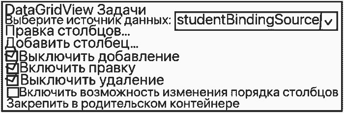

Рис. 2.6. Окно выбора настроек

Страница 34

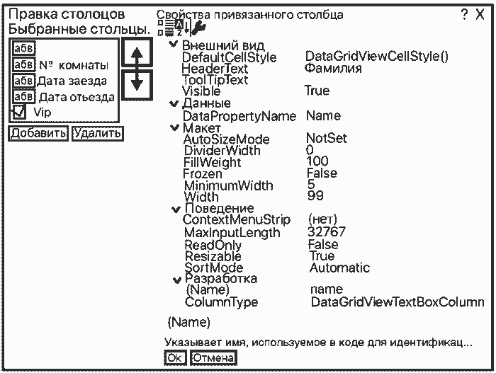

Рис. 2.7. Окно правки столоцов

В левой части окна можно выоирать столоец но его заголовку и выполнять с ним такие действия, кик удаление или перемете ее. Ненужные столбцы можно удалить, однако, чтобы программно получать значения таких столбцов, целесообразнее столбцы не удалять, а сделать их невидимыми. Для этого в примой части окна для выделенного столбца отображения свойство `Visible`. Как было уже отмечено, окно, изображенное на рис. 2.7, можно отобразить, выбрав в окне "Свойства" совйство `Columns` и щелкнув кнопку с тремя точками. Свойства какого-либо выделенного элемента управления мы привыкли править в окне «Свойства», однако выделить столбец таблицы щелчком мыши нельзя. В тоже время Вы можете мы брать столбец из перечня отображаемых объектов, если щелкните кнопку во второй строке окна «Свойства» (под заголовком) и в раскрывшемся окне выберите имя нужного столбца. В результате Вы получите почти тот же перечень свойств, что и на рис. 2.7. Имя столбца формирует конструктор формы, и начинается оно с имени соответствующего столбцу свойства (с маленькой буквы), за которым следует тип этого столбца.

Страница 35

Например, для свойства `Name` класса `Client` имя столбца будет следующим: `nameDataGrid ViewTextBoxColumn`. **Каждый столбец** таблицы во второй части класса Form1 (файл Forml.Designer.cs) представлен отдельным объектом, ссылку на который можно использовать для программного доступа к свойствам столбца. В таблице DataGridView могут находиться столбцы следующих типов: `DataGridViewTextBoxColumn`; `DataGridViewButtonColumn`; `DataGridViewCheckBoxColumn`; `DataGridViewComboBoxColumn`; `DataGridViewlmageColumn`; `DataGridViewLInkColumn`; **По выделенной подстроке можно** догадаться о назначении того или иного типа. Например, тип `DataGridViewButtonColumn` предназначен для отображения в ячейках столбца кнопок. Тип `DataGridViewComboBoxColumn` — для отображения в ячейках столбца комбинированных списков. Тип `DataGridViewImageColumn` - для отображения изображений. Тип `DataGridViewLinkColumn` - для вывода ссылок. Наиболее распространенным типом является `DataGridViewTextBoxColumn`. Этот тип используется для представления строк, числовых данных, данных типа `DateTime` и др. в виде текста, применяя для их отображения метод `ToString`. **Данные типа** `bool` отображаются в столоце типа `DatàGrid ViewCheckBoxColumn` в виде элемента управления `CheckBox` без текста (см. рис. 2.4). Разные типы столбцов имеют слегка отличающийся набор свойств, доступных в визуальном режиме разработки. Рассмотрим свойства столбца типа `DataGridViewTextBoxColumn`, представленные на рис. 2.7.

- **DefaultCellStyle** - получает или задает стиль по умолчанию для всех ячеек столбца.
- **Header Text** - возвращает или задает текст заголовка столбца.

Но умолчанию в качестве заголовка столбца используется имя свойства источника данных, соответствующего столбцу. Как правило, это имя изменяют на более удобное в работе. Зайеним заголовки столбцов нашего примера, разработанного в разделе 2.2, на следующие значения: фамилия; N комнаты; Дата заезда; Дата отьезда. `ToolTipText` возвращает или задает текст, используемый Для подсказок. Этот текст выводится при наведении курсора мыши на заголовок столбца.

Страница 36

Страница 37

# СТИЛЬ ЯЧЕЕК СТОЛБЦА

Свойство `DefaultCellStyle` возвращает объект `DataGridViewCellStyle`, представляющий стиль по умолчанию для ячеек, содержащихся в столбце. Этот стиль примейяется по умолчанию ко всем ячейкам столбца, пока этот стиль не будет переопределен стилем, заданным для конкретной ячейки столбца, или стилем, заданным для всех строк или конкретной строки. То есть, каждая ячейка может получать данные своего стиля из нескольких источников, переопределяя их на разных уровнях. Стиль самого верхнего уровня, применяемый по умолчанию ко всем ячейкам таблицы, определяется свойством `DataGridView.DefaultCellStyle`. Стиль конкретной ячейки определяется свойством `Style` ячейки и переопределяет любые стили, заданные для объектов, включающих ячейку.

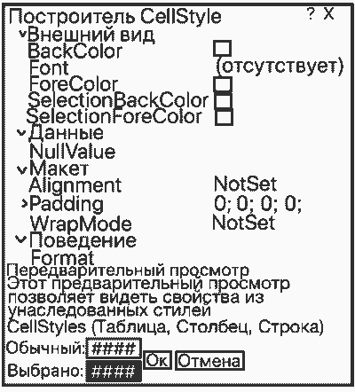

Рис. 2.8. Окно свойств стиля ячеек столбца

Вели выбрать свойство DefaultCellStyle в окне на рис 2.7 щелкнуть появившуюся кнопку с тремя точками, то на экран будет выведено окно свойств, определяющих стиль ячеек столбца (см. рис, 2.8). Окно «Построитель CellStyle» не рис. 2.8 и окно на рис. 2.5 относятся к одному классу и отличаются друг от друга только исходными значениями свойств.

Страница 38

В окне перечистены следющие свойства, определяющие стиль по умолчанию ячеек столбца:

- **BackColor** получает или задает цвет фона ячеек столбца.
- **Font** - получает или задает шрифт, применимый к текстовому содержимому ячеек столбца.
- **ForeColor** - получает или задает основной цвет текста (переднего плана), отображаемого в ячейках столбца,
- **SelectionBackColor** - получает или задает цвет фона, используемый ячейками столбца, когда они выбраны.
- **SelectionForeColor** - получает или задает основной цвет текста, используемый ячейками столбца, когда они выбраны.
- **NullValue** - получает или задает значение ячеек столбца, отображаемое вместо значения `null` (или `DBNull.Value`).
- **Alignment** - получает или задает значение, показывающее положение содержимого в ячейке столбца.
- **Padding** - получает или задает расстояние между краем ячеек столбца и их содержимым.
- **WrapMode** - получает или задает значение, показывающее, переносится ли текстовое содержимое ячеек столбца на последующие строки или обрезается, когда оно слишком длинное и не помещается на одной строке.
- **Format** - получает или задает строку формата, применяемого для формирования текстового содержимого ячеек столбца в соответствии с заданным форматом.

Если для свойства `DataGridView.EnableHeadersVisualStyles` задано значение `true`, то стили группы «Внешний вид» (см. рис. 2.8), установленные для заголовка столбца или строки, игнорируются. Столбец имеет еще ряд свойств, неотображаемых в `Visual Studio`, например свойство `FormatProvider`, которое получает или задает объект, используемый при формирований значений ячеек столбца в соответствии с языком и региональными параметрами. Другое неотображаемое свойство - `DataSourceNullValue`, получает или задает значение, сохраняемое в источнике данных, когда пользователь вводит в ячейку значение `null`. Почти все перечисленные свойства интуитивно понятны. Исключение составляют свойства `NullValue` и `Format`. Опишем эти свойства подробнее. Пусть для столбца «Фамилия» задан стиль `NullValue` со значением «Введите фамилию». Тогда в каждой ячейке, имеющей значение `null` или `DBNull.Value`, будет отображаться значение "Введите фамилию". Если Вы выберите свойство `Format` и щелкните кнопку с тремя точками, то будет отображено окно «Диалог формата строки» (см. рис. 2.9).

Страница 39

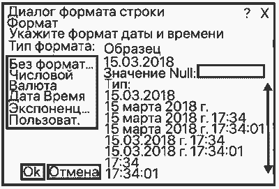

Рис. 2.9. Типы форматов

Страница 40

# НАСТРОЙКА ШИРИНЫ КОНКРЕТНОГО СТОЛБЦА

Выше было отмечено, что для всех столбцов применяются установки по умолчанию, выполненные на уровне свойств таблицы. Однако для конкретного столбца эти установки можно изменить с помощью свойств столбца. Например, можно изменить стили столбца. Также с помощью свойства `AutoSizeMode` столбца можно изменить способ определения ширины данного столбца, заданный по умолчанию на уровне свойств таблицы. **Свойство `AutoSizeMode`** столбца дополнительно к значениям свойства `AutoSizeColumnsMode` таблицы имеет еще одно значение: `NotSet` - режим изменения размеров столбца наследуется из свойства таблицы DataGridView.AutoSizeColumnsMode. Для изменения ширины столбца имеется также свойство `Width`, которое можно установить только для режима `None`. Относительная ширина столбцов в режиме `Fill` определяется значениями свойства `DataGridViewColumn.FillWeight`.

Страница 41

# 2.4. Архитектура DataGridView

### Особенности привязки DataGridView к данным

Привязка таблицы `DataGridView` к источнику данных имеет ряд особенностей. Так, `DataGridView`, в отличие от элементов управления `ListBox` и `ComboBox`, позволяет, используя интерфейс таблицы, вносить изменения в таблицу: удалять строки, добавлять новые записи и изменять содержимое яческ. Такая особенность обусловлена тем, что в режиме привязки данных все значения ячеек для столбцов, связанных с данными, хранятся во внешнем источнике данных. Это означает, что считывание значе ния из ячейки таблицы осуществляется путем выполнения метода `get` свойства, соответствующего ячсикс, а изменсние содержимого ячейки (любым способом) приводит к вызову метода `set` свойства. Программным способом добавлять новые записи в привязанную к источнику данных таблицу нельзя. Поскольку компонент `BindingSource` обеспечивает двустороннюю привязку, то такие операции, как добавление, удаление или изменение записен, могут выполняться или в источнике данных, или в таблице (программным способом или через интерфейс таблицы).

# Реальное и отображаемое значения ячейки.

В режиме привязки каждая ячейка связана с соответствующим ей свойством источника данных. Для доступа к значению ячейки используются два свойства: `Value` и `FormattedValue`. Свойство `Value` ячейки получаст или возвращает значение соответствущего свойства источника данных. Такое значение может иметь тип `int`, `float`, `DateTime`, `string` и т.д. Свойство `FormattedValue` возвращает отформатированное значение, предоставленное свойством `Value`, для его отображения. Ячейка имеет тип, получаемый от столбца, или назначенный разработчиком. По аналогии с типами столбцов, используются следующие типы ячеек: **Во-первых**, `DataGridViewButtonCell`; **Во-вторых**, `DataGridViewCheckBoxCell`; **В-третьих**, `DataGridViewComboBoxCell`; **в четвёртых**, `DataGridViewHeaderCell`; **в пятых**, `DataGridViewImageCell`; **в шестых**, `DataGridViewLinkCell`; **В седьмых**, `DataGridViewTextBoxCell`. Все перечисленные типы являются наследниками типа `DataGridViewCell`.

Страница 42

Наиболее распространенным является тип `DataGridViewTextBoxCell`, используемый для отображения текста. То есть каждое значение свойств источника данных для отображения в таблице преобразуется в строку типа `String`. Именно это значение и возвращает свойство `FormattedValue`, предварительно прочитав реальное значение соответствующего свойства источника данных. Таким образом, в режиме привязки ячейки таблицы не хранят никаких значений. Единственно, что хранит таблица, это ссылки на объекты источника данных. **Для того чтобы понять**, о каком значении идет речь, будем использовать следующие термины: **«реальное значение ячейки»** (или просто «значение ячейки») — это значение из источника данных, которое получает или возвращает свойство ячейки `Value`; **«отформатированное значение ячейки»** (или «отображаемое значение ячейки») — это значение, которое возвращает свойство ячейки `FormattedValue`. **Изменение данных в таблице**. Когда пользователь изменяет значение в ячейке, это значение изменяется непосредственно в источнике данных. Если пользователь создает новый объект с помощью строки для добавления новой записи, новый объект создается конструктором по умолчанию в источнике данных до того, как эта запись будет заполнена. Удаление записи из таблицы, естественно, приводит к удалению соответствующего объекта из источника данных. **Для изменения** содержимого ячеек используются соответствующие методы `set` свойств объектов источника. Никаких обновлений привязки в перечисленных изменения не требуется и не выполняется.

Страница 43

**Изменение источника данных путем добавления или удалення записей**. Изменение источника данных не всегда приводи к автоматическому отображению измененных данных в таблице. Коллекция `List<T>` не уведомляет компонент `BindingSource` о выполненных в списке изменениях. Поэтому, если не обновить приказку, будет наблюдаться несоответствие отображаемого значения реальному. Например, вставим на место второй записи в список `List<T>` новый объект. Таблица будет продолжать отображать старое состояние. Однако, если программным способом прочитать какую-либо ячейку второй записи таблицы, то это будет ячейка другой записи — новой. С удалением записи дело обстоит еще хуже: после удаления записи из списка, количество строк в таблице останется прежним, а в списке все записи, располагающиеся после удаленной, сдвинутея на одну запись к началу списка, то есть записей станет на одну меньше. Таблица попытается прочитать последнюю запись в списке, которой нет, и выдаст серию сообщений об отсутствии последней записи таблицы. Поэтому после добавления записи в список или удаления записи из списка следует тут же обновить таблицу, выполнив оператор `bindingSource.ResetBindings(false);`. Коллекция `BindingList<T>` уведомляет о добавлении новых записей (`Add`, `AddRange`, `Insert`) и об удалении записей (`Remove`, `RemoveAt`), что приводит к перерисовке таблицы.

Страница 44

**Изменение значения отдельного свойства источника данных**. В пользовательском классе разработчики, как правило, не реализуют уведомление связывателя об изменении значений свойств. После изменения какого-либо значения свойства в источнике в таблице по-прежнему будет отображаться старое значение. Однако попытка прочитать ячейку, соответствующую измененному свойству, приведет к чтению нового значения. Связано это с тем, что каждое значение ячейки читается из источника данных. Чтобы таблица вместо старого значения ячейки отобразило новое, разработчик должен перерисовать строку или таблицу. Для этого может быть использован один из следующих методов:

- **ResetItem** - вызывает в таблице, привязанной к компонентy `BindingSource`, повторное считывание элемента источника данных по указанному индексу и обновление его отображаемого значения.
- **ResetBindings** — вызывает в таблице, привязанной к компоненту `BindingSource`, повторное считывание всех элементов источника данных и обновление их отображаемых значений.

Как Вы видите, можно перерисовать одну строку, а не всю таблицу, что предпочтительней с точки зрения производительности. Таким образом, если Вы реализуете алгоритмы добавления или удаления объектов в источнике данных, то используйте сразу же после добавления или удаления метод `ResetBindings`. Если изменяете отдельное значение - `ResetItem`. Если Вы выполняете изменения данных в таблице, дополнительно обновлять отображение ячеек и строк не надо — таблица это сделает за Вас. Какие открытые свойства не отображаются в таблице. Как было отмечено выше, наиболее распространенным типом является `DataGridViewTextBoxColumn`. Для преобразования в текст числовых данных, данных типа `DateTime`, символов и т.д. применяется метод `ToString`. Если класс содержит открытое свойство пользовательского типа, например `public UserClass User { get; set; }`, то в результате привязки столбец для этого свойства создастся, а для отображения значений в столбце будет вызываться метод `ToString` этого типа (то есть само свойство в строку не преобразуется, что естественно). Благодаря тому, что столбец для пользовательского типа создается, можно преобразовать его в тип `DataGridViewComboBoxColumn`, о чем будет рассказано позже. В таблице, привязанной к источнику данных, не для всех открытых свойств создаются столбцы, Например, для следующего свойства столбец создан не будет: `public List< UserClass > User { get; set; }`

Страница 45

# Коллекции таблицы DataGridView

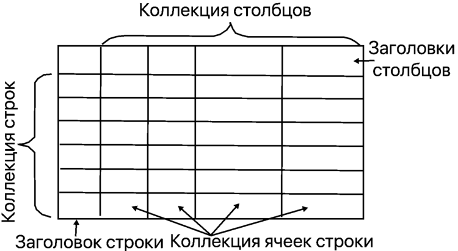

Рис. 2.10. Таблица `DataGridView` и её коллекции объектов

Пользователю чаще всего приходится работать с коллекциями таблицы `DataGridView`, к которым относятся: коллекция столбцов, коллекции строк и коллекции ячеек. **После перетаскивания элемента** управления `DataGridView` на форму среда создаст объект таблицы с именем `dataGridView1`. Разработчик может изменить это имя на более короткое, например `grid1`. **Для работы с** перечисленными коллекциями и их элементами можно использовать соответствующие свойства таблицы `DataGridView`. В коллекцию входят как отображаемые (`Visible=true`), так и неотображаемые (`Visible=false`) объекты (столбцы или строки). Для доступа к элементам коллекций проще всего использовать индексаторы. Нумерация объектов коллекций начинается с нуля. Заголовки строк и столбцов — это ячейки, однако в коллекции ячеек они не входят и не имеют, следовательно, индексов. Заголовки определяются отдельными свойствами соответствующего класса. Ячейка в левом верхнем углу таблицы — это тоже заголовок, который не входит ни в одну из коллекций. Если щелкнуть левую верхнюю ячейку заголовка, будут выбраны все ячейки в элементе управления `DataGridView`.

Страница 46

# НУМЕРАЦИЯ СТРОК, СТОЛБЦОВ И ЯЧЕЕК

На рис. 2.11 показаны координаты различных объектов таблицы. Для доступа к ячейке можно использовать как коллекцию ячеек строки, так и индексатор таблицы. Координаты ячейки в случае использования индексатора таблицы определяются парой индексов — номером столбца (указывается первым) и номером строки (указывается вторым). Обратите внимание: в языке С# двумерные массивы имеют другой порядок следования индексов. Для работы с первым индексом часто используется свойство Х, а со вторым — Y.

Страница 47

[output not shown]

Рис. 2.11. Нумерация объектов таблицы

Невидимые столбцы и строки не изменяют нумерацию. Например, если сделать столбец «Группа» невидимым (`Visual = false`), то столбец «Рейтинг» как был третьим (`индекс=2`), так и останется третьим. **Примечание**. В повседневной жизни принято отсчет вести, начиная с 1, в то время как первый элемент коллекции имеет индекс 0. Имейте в виду, что индекс элемента всегда на единицу меньше его номера.

Страница 48

# ОСОБЕННОСТИ СОЗДАНИЯ НОВОЙ ЗАПИСИ

**После того как пользователь** переместит фокус ввода на строку для добавления новой записи, возможны следующие варианты завершения работы с этой строкой: **Во-первых**, Если пользователь ввел с клавиатуры первый символ в какую-либо ячейку новой строки, фиксируется режим редактирования ячейки. В этом случае создается новая запись в источнике данных; ниже вводимой записи появляется очередная строка для добавления новой записи. Если после заполнения ячеек данными пользователь переместит фокус на любую предшествующую или очередную новую строку, новая запись будет зафиксирована как созданная. Новую запись будем называть зафиксированной, если её добавление нельзя будет отменить клавишей `Escape`. **Во-вторых**, Пользователь не стал редактировать ни одной ячейки (не вошел в режим редактирования) и возвратился на любую предшествующую строку, переместив курсор или нажав `Escape`. В этом случае новая запись создана не будет. **в-третьих**, Как только пользователь впервые входит в режим редактирования какой-либо ячейки, таблица создает новую запись в источнике данных; ниже появляется очередная строка для добавления новой записи. Пользователь заполняет какие-либо ячейки данными, но потом отказывается от создания записи, нажимая клавишу `Escape`. Первое нажатие отменяет редактирование текущей ячейки, а второе приводит к удалению записи из источника данных и перемещению фокуса ввода на предыдущую строку.

**Важное замечание**: при отказе от добавления новой записи с помощью клавиши `Esc` (вариант 2 или 3), осуществляется повторное чтение последней записи коллекции и её отображение в таблице. Если разработчик для отображения записей, соответствующих некоторому критерию, использует свойство `Row.Visible` (см. раздел 2. 12), то этой последней записью может оказаться запись с другим критерием. Возникает некорректная ситуация. Исправить эту ситуацию можно только нетривиальным способом, поэтому лучше отказаться от добавления новой записи с помощью интерфейса таблицы и использовать для добавления отдельную форму (см. раздел 2.12). Тем не менее, в комплексном примере, приведенном в разделе 2.17, показан способ решения этой проблемы (см. событие `RowPostPaint`). ледует заметить также, что независимо от того, создана новая запись или нет, любое перемещение со строки для новой записи на другую строку приводит к появлению события `RowValidated`.

Страница 49

# 2.5. Работа с объектами Datagriaview

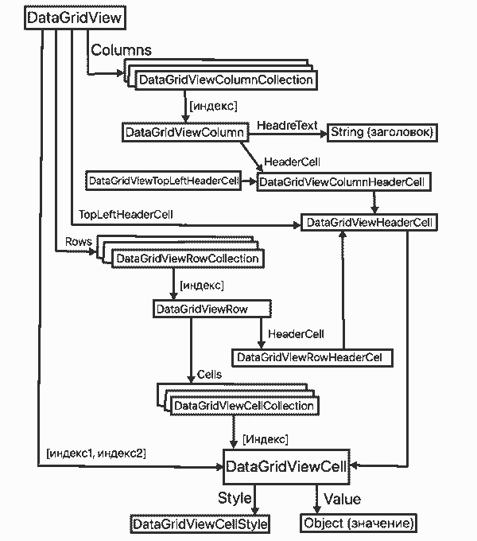

Рис. 2.12. Основные классы таблицы и их взаимосвязи

Страница 50

# ВЗАИМОСВЯЗЬ ОСНОВНЫХ КЛАССОВ ТАБЛИЦЫ

На рисунке 2.12 показаны основные классы таблицы `DataGridView` и их взаимосвязь, реализуемая через свойства и индексаторы классов. Классы показаны в виде прямоугольников с закругленными углами. Коллекции изображены в виде серии из трех прямоугольников. Свойства и индексаторы изображены в виде текста рядом со стрелками. Стрелка → обозначает ассоциативную связь, а стрелка → обозначает наследование.

# КОЛЛЕКЦИЯ СТОЛБЦОВ

Ссылку на коллекцию столбцов можно получить с помощью свойства Columns.  
**Пример**. `dataGridView1.Columns`. **Коллекция столбцов** имеет тип `DataGridViewColumnCollection`, а отдельный столбец — `DataGridViewColumn`. Количество столбцов в коллекции может быть получено или изменено с помощью свойства `DataGridView.ColumnCount`. **Ячейка заголовка** является членом соответствующего столбца. Обычные ячейки в состав столбца не входят, однако через столбец можно задать общие свойства для ячеек всех строк, образующих столбец. **Для выборки** требуемого столбца из коллекции чаще всего используют индексатор. Значением индекса может быть как число, так и строка. Строка задает имя столбца (не путать с заголовком или именем соответстуюшего свойства данных).

**Пример**. Получим первый и четвертый столбцы из таблицы `DataGridView` (см. рис, 2.4).

```
dataGridView1.Columns[0] // столбец "Фамилия"
dataGridView1.Columns("name") // столбец "Фамилия"
dataGridView1.Columns[3] // столбец "Дата отъезда"
dataGridView1.Columns["date2"] // столбец "Дата отьезда"
```

Страница 51

**Заголовок столбца**. Каждый столбец может иметь заголовок типа `DataGridViewColumnHeaderCell`. Текст заголовка можно получить или изменить двумя способами. **Пример**. Изменить текст заголовка первого столбца.

```
dataGridView1.Columns[O].HeaderText = "Ф.И.О." ;
dataGridView1.Columns[O].HeaderCell.Value = "Ф.И.О.";
```

**Пример**. Изменить цвет фона и переднего плана заголовка первого столбца.

```
// Отключить использование в заголовках цветов
// текущей темы Windows.
dataGridView1.EnableHeadersVisualStyles = false;
// Изменить цвета.
dataGridView1.Columns[0].HeaderCell.Style.BackColor = Color.LightYellow;
dataGridView1.Columns[0].HeaderCell.Style.ForeColor = Color.DarkRed;
```

**Пример**. Определить тип четвертого столбца.

```
string typeCell = dataGridView1.Columns[3].ValueType.Name;
```

# КОЛЛЕКЦИЯ СТРОК

Ссылку на коллекцию строк можно получить с помощью свойства `RowS`. **Пример**. `dataGridView1.Rows` Коллекция строк имеет тип `DataGridViewRowCollection`, а отдельная строка — `DataGridViewRow`. Количество строк в коллекции может быть получено или изменено с помощью свойства `DataGridView.RowCount`. Членами строки являются обычные ячейки, образующие строку, и ячейка заголовка. Для выборки требуемой строки из коллекции чаще всего используют индексатор. Значением индекса может быть только число. **Пример**. Получим первую и четвертую строки из таблицы `DataGridView` (см. рис. 2.4).

```
dataGridView1.Rows[0] // Первая строка
dataGridView1.Rows[3] // Четвертая строка
```

**Заголовок строки**. Каждая строка может иметь заголовок типа `DataGridViewRowHeaderCell`. Работа с заголовком строки похожа на работу с заголовком столбца. **Пример**. Изменить текст заголовка первой строки. `dataGridView1.Rows[O].HeaderCell.Value = "Ф.И.О.";`

Страница 52

**Пример**. Изменить цвет фона и переднего плана заголовка первой строки.

```
// Отключить использование в заголовках цветов
// текущей темы Windows.
dataGridView1.EnableHeadersVisualStyles = false;
// Изменить цвета.
dataGridView1.Rows[0].HeaderCell.Style.BackColor = Color.LightYellow;
dataGridView1.Rows[0].HeaderCell.Style.ForeColor = Color.DarkRed;
```

Страница 53

**Строка новой записи**. В коллекцию строк таблицы входи строка для добавления новой записи. С этой строкой может работать только пользователь через интерфейс таблицы. Строка новой записи может отсутствовать, если выполнено одно из следующи из условий: **Во-первых**, отсутствует конструктор по умолчанию у класса, к которому привязана таблица; **Во-вторых**, свойство `dataGridView1.AllowUserToAddRows` имеет значение `false`. **В коде программы**, особенно в циклах по строкам таблицы необходимо учитывать наличие этой строки. Учет строки новой записи. Строка для добавления новой записи, как было сказано, входит в коллекцию строк таблицы, но работать с такой строкой в программном коде нельзя, так как ее ячейки, как правило, имеют значения `null`. Поэтому такую строку необходимо исключать из цикла обработки строк. Если количество строк в таблице определяется свойством `DataGridView.Rows`. `Count`, то достаточно из этого количества вычесть 1. Однако этот способ не является универсальным, так как строку новой записи можно убрать из таблицы с помощью `AllowUserToAddRows=false`.

**Есть несколько универсальных способов**:

- **Способ 1**. Если таблица привязана к источнику данных (например `list`), то количество строк в таблице, не считая строки для новой записи, равно количеству объектов в источнике данных.

**Пример**. Пусть **list** — это ссылка на список типа **List**, используемый в качестве источника данных таблицы. Тогда количество `count` существующих строк в таблице равно: `int count = list.Count;`

Страница 54

**Способ 2**. Узнать, является ли строка строкой для добавления, можно по свойству строки `IsNewRow`, которое возвращает значение `true` или `false`.

**Пример**. Подсчитать количество всех VIP-персон.

```
int s = 0;
for (int i = 0; i < dataGridView1.Rows.Count && !dataGridView1.Rows[i].IsNewRow; i++)
{
    if((bool) dataGridView1["vip", i].Value)
        s++;
}
```

**Способ 3**. Можно заранее выяснить, есть ли строка для добавления или нет, и сформировать поправку. Это необходимо выполнить до привязки таблицы к источнику данных, когда коллекция строк либо пустая, либо состоит из одной строки, которой является строка для добавления новой записи.

**Пример**. Определим наличие строки для добавления новой записи в обработчике `Form_Load`.

```
public int rowAdd; // Наличие строки для добавления нового объекта.
private void Form1_Load(object sender, EventArgs e)
{
    rowAdd = dataGridView1.Rows.Count;
    //...
}
```

Далее, корректируем цикл:

```
int count = dataGridView1.Rows.Count - rowAdd;
int s = 0;
for (int i = 0; i < count; i++)
{
    if ((bool)dataGridView1 ["vip", i].Value)
        s++;
}
```

Страница 55

# КОЛЛЕКЦИЯ ЯЧЕЕК

Ячейки образуют коллекцию ячеек строки. Ячейка является объектом типа `DataGridViewCell`, имеющим множество свойств. Наиболее значимыми свойствами являются следующие:

- **Value** — получает или задает значение, связанное с этой ячейкой. Это реальное значение ячейки (свойства источника данных), а не отображаемое в ячейке. Например, реальным значением может быть номер вуза, а отображаемым — его название. К сожалению, это значение имеет тип `object` и его необходимо приводить к типу соответствующего свойства источника данных.
- **ValueType** - получает или задает тип данных для значений в ячейке. Это свойство, как правило, возвращает тип данных источника привязки.
- **FormattedValue** - получает значение ячейки, отформа тированное для отображения. Это значение, как правило, можно привести к типу `string`.
- **ColumnIndex** — получает индекс столбца для данной ячейки.
- **RowIndex** — получает индекс родительской строки ячейки.
- **Style** - получает или задает стиль ячейки.
- **InheritedStyle** — получает стиль, применяемый в текущий момент к ячейке. Элемент управления `DataGridView` отображает ячейки, используя стили, указываемые свойством `InheritedStyle` ячейки, которое наследует стили из других свойств типа `DataGridViewCellStyle`.

Стили, задаваемые свойством `Style`, переопределяют стили, задаваемые всеми другими свойствами стиля ячейки, но не обязательно показывают все стили, которыми определяется внешний вид ячейки.

- **ReadOnly** - получает или задает значение, показывающее, можно ли изменять данные в ячейке.

Страница 56

Обратите внимание: свойства `Value` и `FormattedValue` возвращают значения типа `Object`, поэтому при чтении значения необходимо приведение типа или использование метода `ToString`. **Существует два способа** доступа к ячейкам таблицы: **Во первых**, используя коллекцию ячеек конкретной строки; **Во вторых**, используя индексатор таблицы DataGridView.

**Первый способ**. Каждая строка таблицы состоит из коллекции типа `DataGridViewCellCollection` ячеек типа `DataGridViewCell` и ячейки заголовка типа `DataGridViewRowHeaderCell`. Получить коллекцию яческ можно с помощью свойства `Cells`. Имея коллекцию яческ, можно получить доступ к нужным ячейкам по их индексам.

```
string fam = (string)dataGridView1.Rows[1].Cells[0].Value;
```

В качестве индекса коллекции можно использовать имя столбца.

**Пример**. Получить содержимое ячейки второй строки столбца «name».

```
string fam = (string)dataGridView1.Rows[1].Cells["name"].Value;
```

**Второй способ**. Таблица `DataGridView` имеет индексатор с двумя индексами, которые однозначно определяют ячейку. Первый индекс определяет номер или имя столбца, а второй — номер строки. На пересечении столбца и строки находится требуемая ячейка.

**Пример**. Получить содержимое первой ячейки второй строки.

```
string fam = (string)dataGridView1[0, 1].Value;
```

В качестве индекса можно использовать имя столбца.

Страница 57

**Пример**. Получить содержимое ячейки столбца «name» второй строки.

```
string fam = (string) dataGridView1.Rows["name", 1].Value;
```

**Пример**. Изменить цвет фона и переднего плана ячейки с координатами (1, 2). Поскольку цвета текущей темы `Windows` используются только для заголовков, отключать тему не обязательно.

```
dataGridView1[1, 2].Style.BackColor = Color.LightYellow;
dataGridView1[1, 2].Style.ForeColor = Color.DarkRed;
```

**Пример**. Определить тип ячейки столбца «День приезда» первой строки (см. рис. 2.4).

```
string typeBD = dataGridView1["date1", 0].ValueType.Name;
```

Страница 58

# ВЫБРАННЫЕ СТРОКИ, СТОЛБЦЫ И ЯЧЕЙКИ

Таблица `DataGridView` поддерживает понятие «выбранная коллекция объектов» и «текущий объект». Пользователь может выбрать несколько строк, столбцов или ячеек, если свойство `DataGridView.MultiSelect` равно `true`. Это стандартное значение. На практике выборка коллекции строк чаще всего используется для их одновременного удаления. В остальных случаях, как правило, используется только первая строка или столбец коллекции. Свойство `DataGridView.SelectionMode` возвращает или задает значение, указывающее, каким образом могут быть выбраны ячейки объекта `DataGridView`. Возможные значения задает перечисление `DataGridViewSelectionMode`:

- **CellSelect** - можно выбрать одну или несколько отдельных ячеек. Строку или столбец выбирать нельзя.
- **FullRowSelect** - вся строка выбирается путем щелка заголовка строки или ячейки, содержащейся в этой строке. Выбрать отдельную ячейку нельзя.
- **RowHeaderSelect** - строка может быть выбрана путем щелчка заголовка строки. Отдельную ячейку можно выбрать, щелкнув ее.
- **FullColumnSelect** - весь столбец может быть выбран путем щелчка заголовка столбца или ячейки, содержащейся в этом столбце.
- **ColumnHeaderSelect** — столбец будет выбран путем щелчка ячейки заголовка столбца. Отдельную ячейку можно выбрать, щелкнув ее.

По умолчанию установлено значение `RowHeaderSelect`, определяющее, что строку можно выбрать, щелкнув заголовок. Выбранные объекты оформляются в виде коллекций. Соответствующую коллекцию можно получить с помощью свойств:

- **SelectedCells** - получает коллекцию ячеек, выбранных пользователем.
- **SelectedColumns** - получает коллекцию столбцов, выбранных пользователем.
- **SelectedRows** - получает коллекцию строк, выбранных пользователем.

Для перебора всех объектов коллекции обычно используют цикл. Практика показала, что порядок следования объектов в коллекции зависит от направления выборки объектов пользователем и положения текущей строки. Текущей строкой является строка с маркером -> в заголовке строки. Если группа строк выбрана сверху вниз, то текущей строкой станет последняя строка группы. В этом случае отобранные строки будут помещены в коллекцию в последовательности от текущей (последней) строки группы до первой строки группы. Если группа строк выбрана снизу вверх, то текущей строкой станет первая строка группы. В этом случае отобранные строки будут помещены в коллекцию в последовательности от текущей (первой) строки группы до последней строки группы. Если выбирается блок ячеек (см. рис. 2.13), то коллекция строк не создается, а в коллекции яческ выбранные ячейки следу ют в порядке обратном их выделению.

Страница 59

Form1 _OX

|  | Фамилия | № комнаты | Дата заезда |
| --- | --- | --- | --- |
| Иванов | 101 | 22.04.2018 | 22.05.2018 |
| Николаев | 103 | 12.05.2018 | 22.07.2018 |
| Сидоров | 201 | 15.06.2018 | 30.06.2018 |
| Титов | 202 | 13.07.2018 | 22.07.2018 |
| Cepreeв | 205 | 19.08.2018 | 22.08 2018 |

Кнопки: Добавить; Изменить; Удалить;

Так, для рис. 2.13 в коллекции ячеек, выбранных сверху вниз и слева направо, ячейки будут располагаться в следующей последовательности:

- 201 - Сидоров
- 103 - Николаев
- 101 - Иванов

Разработчик должен учитывать тот факт, что пользователь может выбирать ячейки непредсказуемым образом.

Страница 60

**Пример**. Получим первую выделенную в таблице на рис. 2.13 ячейку.

```
int index = dataGridView1.SelectedCells.Count - 1;
string fam = dataGridView1.SelectedCells[index].Value.ToString();
```

В результате выполнения фрагмента получим: `fam = Иванов`. **Рекомендация**. Если Вы специально не решаете задачу обработки блоков выбранных ячеек, строк или столбцов, то установите свойство `MultiSelect` таблицы в значение `false`. Коллекции выбранных объектов все равно будут создаваться, но они будут состоять только из одного объекта.

# ТЕКУЩИЕ СТРОКИ И ЯЧЕЙКИ

Если нужен только текущий объект, то, несмотря на выборку нескольких объектов, проще использовать следующие свойства:

**CurrentCell** - возвращает или задает текущую активную ячейку или значение `null`, если текущая ячейка отсутствует. Текущей ячейкой является выделенная цветом ячейка. Если выделена группа ячеек, то текущей ячейкой является ячейка в текущей строке. Текущая ячейка не может быть ячейкой заголовка, отключенной ячейкой или ячейкой в скрытом столбце или строке. Для свойства `CurrentCell` может быть задано значение `null`, чтобы временно удалить прямоугольник фокуса.

**Пример**. Отключить текущее выделение ячейки и строки. `dataGridView1.CurrentCell = null;`. Обычно такую операцию выполняют, прежде чем скрыть строку, так как нельзя скрывать строку, содержащую активную ячейку. Когда таблица получает фокус и значением свойства `CurrentCell` является `null`, выделяется ячейка, находящаяся в левом верхнем углу, или та, которую пользователь щелкает мышью. Когда выполняется привязка таблицы к внешнему источнику данных, свойство CurrentCell сбрасывается в свое значение по имолнянию,

Страница 61

**CurrentCellAddress** - получает индексы строки и столбца ячейки, которая в данный момент является активной.

**CurrentRow** — получает строку, содержащую текущую ячейку или значение `null`, если текущая ячейка отсутствует. Текущей строкой является строка с маркером -> в заголовке строки. При выделении отдельной ячейки строка с этой ячейкой становится текущей, и свойство `CurrentRow` возвращает эту строку. Если выбрано несколько строк, то текущей строкой является либо первая, либо последняя строка группы. Расположение текущей строки в группе зависит от того, как выбираются строки - сверху вниз или снизу вверх. Текущая строка в группе та, которую последней покинул курсор мыши. Текущей строкой может быть только одна строка.

**Пример**. Получить фамилию из текущей строки.

```
string fam = (string)dataGridView1.CurrentRow.Cells[0].Value;
```

**Пример**. Получить координаты текущей ячейки. Х — номер столбца, Y — номер строки.

```
int X = dataGridView1.CurrentCellAddress.X;
int Y = dataGridView1.CurrentCellAddress.Y;
```

**Пример**. Определить тип текущей ячейки.

```
string typeCell = dataGridView1.CurrentCell.ValueType.Name;
```

**Пример**. Определить индекс текущей строки и отобразить в элементах управления `textBox1` и `textBox2` значения свойств `Name` и `Room`. Значения получить из источника данных.

```
i = dataGridView1.CurrentRow.Index;
textBox1.Text = list[i].Name;
textBox2.Text = list[i].Room.ToString();
```

Страница 62

# УГЛОВОЙ ЗАГОЛОВОК

Речь идет о левой верхней ячейке, расположенной на пересечении заголовка строк и заголовка столбцов. Угловой заголовок не связан ни с коллекцией столбцов, ни с коллекцией строк, поэтому он привязывается с помощью свойства `TopLeftHeaderCell` к самой таблице. Щелчок на ячейке углового заголовка приводит к выделению всех строк таблицы. Существует класс `DataGridViewTopLeftHeaderCell`, который специально предназначен для работы с угловым заголовком. Этот класс ничего нового по сравнению с классом `DataGridViewHeaderCell` практически не предлагает. **Пример**. Записать значение в угловой заголовок. `dataGridView1.TopLeftHeaderCell.Value = "Строки / Столбцы";`

# 2.6. Стандартный интерфейс таблицы DataGridView

Рассмотрим поведение `DataGridView`, установленное по умолчанию. Если поместить новый `DataGridView` на форму и не производить никаких специальных настроек, то `DataGridView` будет:

Страница 63

- **Во-первых**, автоматически показывать заголовки колонок и заголовки строк; И те, и другие остаются видимыми при любом скроллинге.
- **Во-вторых**, помечать текущую строку маркером ;
- **В-третьих**, выделять всю строку, если пользователь щелкнет по заголовку строки;
- **В четвёртых**, выделять сразу несколько (в том числе несмежных) строк, если щелчок по заголовку строки производится с нажатой клавишей `Ctrl` или `Shift`; Группу смежных строк можно выделить с помощью нажатой левой клавиши мыши. При этом текущая строка (помеченная маркером ») всегда будет единственной.
- **В пятых**, выделять цветом ячейку, имеющую фокус ввода; Строка с этой ячейкой становится текущей.
- **В шестых**, выделять цветом несколько ячеек, используя ту же технику, что и для выделения строк;
- **В седьмых**, осуществлять автоподборку ширины столбца по содержимому, если пользователь выполнит двойной щелчок по правому разделителю столбца в области заголовка;
- **В Восьмых**, осуществлять изменение ширины столбца, если пользователь выполнит перемещение правого разделителя столбца в области заголовка;
- **В Девятых**, если в методе `Main` приложения перед методом Run, вызвать метод `Application.EnableVisualStyles()`, то будет применяться стиль `Windows`, выбранный в настройках рабочего стола;
- __В десятых __, если пользователь щелкнет по заголовку столбца таблицы в непривязанном к источнику данных режиме, строки будут автоматически отсортированы по содержимому столбца.

Помимо этого, `DataGridView` поддерживает изменение содержимого таблицы:

- **во-первых**. Если пользователь выделит строку или несколько строк и нажмет клавишу `Delete`, все выделенные строки будут удалены.
- **Во-вторых**. Если пользователь выполнит двойной щелчок ячейки (или нажмет на ней F2), данная ячейка будет переведена в режим редактирования.
- **В-третьих**. Если пользователь изменит хотя бы один символ в редактируемой ячейке, на заголовке соответствующей строки появится спецсимвол (пишущий карандашик), и будет отображаться до тех пор, пока фокус ввода не покинет редактируемую ячейку, или пока пользователь не нажмет Esc. Последнее действие восстановит то значение ячейки, которое она содержала до входа в режим редактирования.
- **В четвёртых**. Если пользователь прокрутит таблицу вниз до последной строчки, он увидит пустую строку, помеченную символом звездочки на заголовке. Эта строка предназначена для создания и добавления в таблицу (в источник данных) новогообъекта. Будем такую строку называть строкой новой записи. При определенных условиях ячейки строки новой записи могут быть заполнены данными. Когда пользователь любым способом перемещается в эту строку, `DataGridView` добавляет новую запись со значениями по умолчанию и предоставляет пользователю возможность ввести новые данные. Если фокус ввода находится в этой строке, и пользователь нажимает Esc, новая запись пропадает, а фокус ввода перемещается на строчку выше. Если пользователь после редактирования какой-либо ячейки переместит фокус ввода на любую другую строку, то новая запись будет добавлена в таблицу (источник). Строка новой записи присутствует не всегда. Эта строка появляется при выполнении нескольких условий, одним из которых является наличие у класса, к которому привязывается таблица в визуальном режиме разработки, конструктора по умолчанию. Практически всё из перечисленного выше может быть разрешено, запрещено, настроено.

Страница 64

# 2.7. Проблемы редактирования ячеек

При редактировании ячеек существующей или добавляемой записи возникает ряд проблем, связанных с вводом данных по определенному формату и проверкой вводимых значений.

- **Во-первых**, вводимое значение должно соответствовать типу свойства источника данных, которое должно отображаться в ячейке. Например, нельзя в ячейку вводить текст, не являющийся числом, если свойство, соответствующее ячейке, имеет числовой тип. В ячейку для свойства `DateTime` можно вводить только дату и/или время.
- **Во-вторых**, разные ячейки одной записи могут иметь зависимые значения. Например, дата приезда не может больше даты отьезда. Если тип вводимого значения можно проверить в момент его ввода, то значения зависимых ячеек можно проверить только после завершения редактирования строки. Связано это с тем, что разработчик во время редактирования отдельной ячейки не может вынести суждение о том, что редактирование зависимых ячеек было завершено.
- **В-третьих**, иногда необходима подмена реального значения другим, отображаемым. Например, если число 0, свидетельствует об отсутствии значения, то лучше отобразить в ячейке пустое значение.
- **В-четвертых**, для ввода сложных значений, например даты, целесообразно использовать специальный элемент управления, например `MonthCalendar`, который желательно отображать рядом с редактируемой ячейкой. Использование элементов управления для ввода значений позволяет получить одинаковое представление вводимых данных.
- **В-пятых**, удаление выделенных строк пользователем осуществляется без дополнительного разрешения и безвозвратно. Здесь перечислена только часть проблем. Ниже будет показано, как с использованием обработчиков различных событий таблицы решаются перечисленные выше проблемы.

Страница 65

# 2.8. Проверка значений, введенных в ячейки

### ОБЩИЕ СВЕДЕНИЯ

Проверка значений ячеек таблицы, является одной из основных задач, решаемых разработчиком. Эта задача разбивается на следующие подзадачи: **во-первых**. Проверка корректности значений, вводимых в ячейки. **во-вторых**. Проверка ячеек на отсутствие значений. **в-третьих**. Проверка согласованности зависимых ячеек одной строки. **Большинство задач**, связанных с таблицей, решается с помощью обработки событий таблицы. Число этих событий, как уже было отмечено, превышает 180. Ниже будут рассмотрены только события, используемые нами для решения наиболее распространенных задач. **Ввеленное значение может** быть некорректным по причине его несоответствия типу исходного свойства. Например, если тип свойства `uint`, то вводить в ячейку можно только положительные целые числа. Перед записью значения в источник данных специальный объект, связанный с компонентом `BindingSource`, автоматически проверяет корректность введенного значения (значение преобразуется с помощью метода `Parse`) и в случае обнаружения ошибки генерирует событие `DataError`. Если программа не перехватывает это событие, то система выдает окно с информацией об ошибке. Такое окно слишком перегружено малопонятной пользователю информацией, поэтому разработчики иногда сами обрабатывают событие `DataError`, а чаще всего, делают проверку ячейки до её анализа в `BindingSource` и устраняют все ошибки.

Страница 66

Страница 67

# ПРОВЕРКА ЗНАЧЕНИЯ НА УРОВНЕ ЯЧЕЙКИ

Обработчик события `CellValidating`. Рассмотрим параметры обработчика события `CellValidating` на примере таблицы `dataGridView1`. Формат заголовка:

```
dataGridView1_CellValidating (object sender,DataGridViewCellValidatingEventArgs e)
```

Параметр `е` имеет следующие свойства:

- **ColumnIndex** — индекс столбца с текущей ячейкой.
- **RowIndex** — индекс строки с текущей ячейкой.
- **Cancel** — значение true, если событие следует отменить, в противном случае (по умолчанию) — значение false. Значение `true` не позволит Вам оставить ячейку неотредактиро-cванной и перейти на другую ячейку. При входе в обработчикcсвойство `Cancel` по умолчанию имеет значение `false`.
- **FormattedValue** - текст, введенный пользователем в текущую ячейку посредством пользовательского интерфейса. Это значение можно проверить до его присваивания свойству `Value`. Свойство FormattedValue доступно только для чтения.

Страница 68

Обработка события `CellValidating` применяется для проверки содержимого ячейки, теряющей фокус ввода. Такая ячейка является текущей. Событие `CellValidating` происходит так же и при добавлении новой строки, когда пользователь перемещается из одной ячейки в другую. Если событие `CellValidating` отменяется, то текущая ячейка остается в состоянии редактирования, пока не будет установлено `e.Cancel=false`. Старое значение в ячейке можно восстановить, нажав `Escape`. Если установлено `e.Cancel=false`, значение еще раз проверяется объектом, связанным с привязкой (`BindingManagerBase`), и если разработчик что-то не учел, объект может сгенерировать событие `DataError`. Если все нормально, значение присваивается свойству источника данных. **Если пользователь ввел в ячейку**, теряющую фокус ввода, новое значение, то в обработчике события `CellValidating` будут доступны и старое, и новое значения. Старое значение можно прочитать с помощью свойства `Value` (фактически из источника данных) с помощью выражения: `dataGridView1[e.ColumnIndex, e.RowIndex].Value`. **Новое значение** возвращается свойством `е.FormattedValue`. **Новая запись**, как известно, создается конструктором по умолчанию. Если в этом конструкторе свойствам не присваиваются значения, то числовые поля по умолчанию получают значение `0`, строки — `null`, а объекты `DateTime` — значение `01.01.0001:00.00.00`. Если осуществляется перемещение курсора из таких ячеек в другую без ввода нового значения, то новое значение, возвращаемое свойством `FormattedValue`, для разных типов ячеек будет следующим:

| Тип ячейки | Value | FormattedValue |
| --- | --- | --- |
| string | null | " " |
| числа | 0 | "O" |
| DateTime | 01.01.0001 00.00.00 | " " |

Страница 69

Как следует из таблицы. отформатированное значение для свойств числового типа не может быть пустым или `null` значением. Поэтому на пустое или `null` значение обычно проверяют данные типа `string` или `DateTime`. **Для того чтобы уменьшить объем** проверок, можно отдельным полям присвоить начальное значение в конструкторе по умолчанию. Напомним, что конструктор по умолчанию класс `Client`, созданного для нашего приложения, выглядит следующим образом:

```
public Client()
{
    // Текущие даты.
    Date1 = DateTime.Now.Date;
    Date2 = DateTime.Now.Date;
}
```

Благодаря этому конструктору, в новой записи всегда отображается текущая дата. которую легче изменить, чем ввести заново. **Есть и другие способы**. например. использовать обработку события `DefaultValuesNeeded` или установку стиля для значения `null`. Событие `DefaultValuesNeeded` происходит, когда пользователь щелкает на строке для новой записи, после чего она может быть заполнена разработчиком значениями по умолчанию. Это событие возникает перед событием `RowAdded` и событием `CellBeginEdit`.

Страница 70

**Недостатки события_ `CellValidating`: __Во первых**, Это событие порождает множество проверок, не связанных с выводом данных в ячейка. **Во вторых**, Если пользователь пропустил какую-либо ячейку, то в ней может оказаться недопустимое по смыслу значение. **С помощью этого события** нельзя проверить допустимость значений взаимосвязанных ячеек. Поскольку событие `CellValidating` появляется только для одной ячейки, никогда нельзя утверждать, что все зависимые ячейки изменены и готовы для проверки.

**Пример**. Анализ ячеек разного типа для разрабатываемого нами приложения.

```
// Проверяем отдельные ячейки при потере ими фокуса ввода.
private void dataGridView1_CellValidating(object sender, DataGridViewCellValidatingEventArgs e)
{
    string valueNew = e.FormattedValue.ToString().Trim();
    string nameValue = dataGridView1.Columns[e.ColumnIndex].Name;
    uint vUInt;
    DateTime dt;
    int Y = e.RowIndex;
```

Страница 71

```
    switch (nameValue)
    {
        // Поле типа string.
        case "name": if(valueNew == "")
        {
            dataGridView1.Rows[Y].ErrorText = "Поле \"Фамилия\" не должно быть пустым."
            Msg("Поле \"Фамилия\" не должно быть пустым.");
            e.Cancel = true; // Значение не принято.
            return;
        } break;
        // Поле типа uint.
        case "room": if (!uint.TryParse(valueNew, out vUInt))
        {
            dataGridView1.Rows[Y].ErrorText = "Поле \"N° комнаты\" должно быть числом.";
            Msg ("Поле \ "N® комнаты)" должно быть числом.");
            e.Cancel = true; // Значение не принято.
            return;
        } break;
```

```
        // Поле типа DateTime.
        case "date1": if (valueNew == "" || !DateTime. TryParse(valueNew, out dt)
        {
            dataGridView1.Rows[Y].ErrorText =
                "Поле \"Дата заезда\" должно "
                + "иметь формат дд.мм.гггг"
            ;
            Msg("Поле \"Дата заезда\" должно " + "иметь формат дд.мм.гггг");
            e.Cancel = true; // Значение не принято.
            return;
         } break;
```

```
        // Поле типа DateTime.
        case "date2": if (valueNew == "" || !DateTime.TryParse(valueNew, out dt))
        {
            dataGridView1.Rows[Y].ErrorText =
                "Поле \"Дата отъезда\" должно "
                + "иметь формат дд.мм.rrгг "
            ;
            Msg("Поле \"Дата отъезда\" должно " + "иметь формат дд.мм.rrrr");
            e.Cancel = true; // Значение не принято.
            return;
        } break;
    }
    // Значение принято. Сбросить значок ошибки.
    dataGridView1.Rows[Y].ErrorText = "";
}
```

Страница 72

**Метод Msg** — это укороченная версия `MessageBox.Show`:

```
public void Msg (string str)
{
    MessageBox.Show(str, "Ошибочное значение!"
        , MessageBoxButtons.OK, MessageBoxIcon.Error
    );
}
```

Назначение и использование свойства `ErrorText` описано в следующем подразделе.

**Универсальная проверка форматов значений**. В основе этой проверки лежит определение типа значения ячейки и выполнение проверки с помощью метода `TryParse`. Пример:

```
private void dataGridView1_CellValidating(object sender, DataGridViewCellValidatingEventArgs e)
{
    string formattedValue = e.FormattedValue.ToString();
    switch (dataGridView1[e.ColumnIndex, 0].ValueType.Name)
    {
        case "DateTime":
            DateTime d;
            if (!DateTime.TryParse(formattedValue, out d))
        {
            MessageBox.Show(
                "Поле должно содержать "
                + "корректное значение даты!"
                , "Ошибка ввода данных"
                , MessageBoxButtons.OK
                , MessageBoxIcon.Error
            );
            e. Cancel = true;
        } break;
```

Страница 73

```
        case "Int32":
            int di;
            if (!int.TryParse(formattedValue, out di))
        {
            MessageBox.Show("Поле должно содержать"
                + "корректное целочисленное значение!"
                , "Ошибка ввода данных"
                , MessageBoxButtons.OK
                , MessageBoxIcon.Error
            );
            e.Cancel = true;
        } break;
```

```
        case "Single":
            float df;
            if (!float. TryParse(formattedValue, out df))
        {
            MessageBox.Show("Поле должно содержать"
                + "корректное вещественное значение"
                + "(пример: 4,25)!", "Ошибка ввода данных"
                , MessageBoxButtons.OK
                , MessageBoxIcon.Error
            );
            e.Cancel = true;
        } break;
    }
}
```

Страница 74

**Подведем итог**. Проверку ячейки лучше всего выполнять в обработчике события `CellValidating`, так как: **Во первых**, можно запретить пользователю выход из ячейки с неправильным значением (переход фокуса на другую ячейку), задав `e.Cancel=true`; **во вторых**, событие генерируется и при переходе с ячейки на ячейку новой записи; **в третьих**, этот обработчик получает управление даже тогда, когда редатирования не было и в ячейке осталось пустое значение, которое может быть недопустимым.

**Примечание**. В обработчик события `CellValidating` нельзя помещать вызов метода `BindingSource`. `ResetBindings`, так как произойдет зацикливание: `ResetBindings` будет порождать новые события `CellValidating`. Обработчик события `CellValueChanged` не создает таких проблем.

# ИНДИКАЦИЯ ОШИБКИ

Каждая строка и ячейка таблицы имеют свойство `ErrorText`. Если этому свойству присвоить какое-либо значение, например

```
dataGridView1.Rows[e.RowIndex].ErrorText = "Сообщение об ошибке";
```

то в заголовке строки появится значок ошибки (см. рис. 2.14). Сообщение появляется тогда, когда пользователь наводит курсор на значок ошибки. Чтобы убрать из заголовка строки этот значок, необходимо очистить свойство `ErrorText`:

```
ErrorText = "";
```

Свойство ErrorText не связано с событиями, поэтому выполнять очистку можно в любом обработчике, но только после того, как ошибка исправлена. **Примечание**. Если в ячейке отображается курсор, то значок в ячейке не появится, пока ячейка не потеряет фокус ввода. Поэтому рекомендуется для вы вода сообщения об ошибке использовать класс `MessageBox`. Другой вариант - использовать сообщение уровня строки (см. рис. 2.14).

Страница 75

Form _OX

|  | Фамилия | № комнаты | Дата заезда | Vip |
| --- | --- | --- | --- | --- |
| Иванов | 101 | 22.04.2018 | 22.05.2018 | [ ] |
| Николаев | 103 | 12.05.2018 | 22.07.2018 | [ ] |
| Сидоров | 201 | 15.06.2018 | 30.06.2018 | [ ] |
| Титов | 202 | 13.07.2018 | 22.07.2018 | [x] |
| Cepreeв | 205 | 19.08.2018 | 22.08 2018 | [ ] |

Кнопки: Добавить; Изменить; Удалить;

Рис. 2.14. Индикация ошибки

# ПРОВЕРКА ЗНАЧЕНИЙ НА УРОВНЕ СТРОКИ

**Событие `RowValidating`**. Как было отмечено выше, событие `CellValidating` не годится для проверки зависимых ячеек. Необходимо событие, предоставляющее в распоряжение разработчика строку таблицы целиком после завершения всех изменений. Таким событием является `RowValidating`. По своей функциональности это событие похоже на событие `CellValidating`, рассмотренное выше. Отличие состоит в том, что, если событие `CellValidating` происходит для ячейки, которая теряет фокус ввода, то событие `RowValidating` происходит для строки, которая теряет фокус ввода. Благодаря этому, данное событие можно использовать для выполнения проверки всех значений в строке.

Страница 76

**Обработчик события `RowValidating`**. Рассмотрим параметры обработчика события `RowValidating` на примере таблицы `dataGridView1`. Формат заголовка:

```
dataGridView1_RowValidating (object sender, DataGridViewCellCancelEventArgs e)
```

Параметр `е` имеет следующие свойства:

- **ColumnIndex** — индекс столбца ячейки в текущей строке, с которой осушествляется переход.
- **Rowindex** — индекс текущей строки.
- **Cancel** — значение `true`, если событие следует отменить, в противном случае - значение `false`. Значение `true` не позволит пользователю оставить текущую строку неотредактированной и перейти на другую строку. При входе в обработчик свойство `Cancel` по умолчанию имеет значение `false`.

Поскольку в распоряжении разработчика находятся все ячейки, он может проверить каждую по отдельности и в сочетании друг с другом. Казалось бы, имея событие `RowValidating`, можноcотказаться от проверки ячеек в обработчике события `CelIValidating`. Однако это не так. Если разработчик не отреагирует на ошибочные значения в обработчике `CellValidating`, то на них отреагирует система возбуждением события `DataError` и выводом окна с описание ошибки. Событие `DataError` происходит после `CellValidating`, но до `RowValidating`. Следуст заметить: при переходе фокуса на другую строку управление также получает и обработчик события `CellValidating`.

Страница 77

**Особенности работы с новой строкой**. Событие `RowValidating` происходит так же и при добавлении новой записи, когда пользователь перемещает фокус из новой строки в любую другую. Если строка не прошла проверку, задайте `Cancel-true`. Отмена этого события запрещает пользователю выход из недопустимой строки и предотвращает ее сохранение во внешнем источнике данных в режиме привязки данных. Новая запись добавляется в коллекцию записей после начала редактирования хотя бы одной ячейки. Пока пользователь не воЙдет в режим редактирования, новая запись создана не будет. В режим редактирования можно войти или щелкнув выделенную ячейку (если ячейка не выделена, то два щелчка), или начав вводить символ в выделенную ячейку. Как только новая запись создается ниже этой записи создается и очередная новая строка. В результате перехода на другую строку (включая новую строку) после редактирования запись фиксируется как созданная и остается в коллекции. Отказаться от добавления новой записи после перехода на новую строку, но до вхождения в режим редактирования ячейки можно просто возвратившись с новой строки на любую старую строку или нажав клавишу `Escape`. В этом случае новая запись не добавляется в источник данных, но, тем не менее, возникаст событие `RowValidating`, обработка которого для этой ситуации часто приводит к ошибкам, так как ячейки строки для новой записи имеют значение `null`. **Если пользователь начал** редактировать какую-либо ячейку новой записи, запись сразу же добавляется в источник данных, но пользователь (пока запись не потеряла фокус) может отказаться от этой записи. Для этого необходимо нажать два раза клавишу `Escape`. Первый раз - для восстановления исходного значения текущей ячейки (и выходу из режима редактирования) и второй раз - для отказа от новой записи. В этом случае система вернет строку для новой записи в исходное состояние (все значения равны `null`), а новая запись будет автоматически удалена системой из источника с помощью метода `Remove`. К сожалению, этот метод выполняется после возникновения события `RowValidating`, обра ботка которого для этой ситуации, часто приводит к ошибкам, так как запись еще не удалена, а ячейки новой строки, соответствующей записи, имеют значение `null`.

Страница 78

Реакция таблицы на клавишу Escape разная для новой и старой записей. Для новой записи нажатие на клавишу Escape приводит к восстановлению исходного значения редактируемой текущей ячейки. Если ячейка не находится в режиме редактировани то нажатие на клавишу Escape приводит к отказу от новой записи. Для существующей строки нажатие на клавишу `Escape` не приводит к отказу от текущей записи. Без дополнительных усилий в обработчике события `RowValidating` нельзя определить, какая запись предоставлена для проверки: старая, отредактированная новая или запись, подлежащая автоматическому удалению. **На основе вышеизложенного** можно сделать следующий вывод. В обработчике события `RowValidating` не следует проверять ячейки текущей строки для следующих ситуаций: **Во первых**, не было редактирования ни одной из ячеек текущей строки; **Во вторых**, текущая строка является новой записью и был выполнен отказ от её добавления с помощью клавиши `Escape`. **К сожалению**, не существует события, которое могло бы предоставить в распоряжение разработчика окончательно добавленную запись, которая не может быть удалена клавишей `Esc`. **Также можно отметить** следующий недостаток события `RowValidating`. Это событие возникает достаточно часто и чаще всего, когда никакого редактирования ячеек не было, и поэтому проверять ячейки не нужно, однако проверка выполняется, так как, не прибегая к реализации специального алгоритма, нельзя определить, в каком состоянии находится строка, для которой произошло событие `RowValidating`. **Мы решим отмеченные проблемы**, используя специальную методику, предлагаемую в данном учебнике.

Страница 79

**Примечание**. Будем называть новую запись зафиксированной в источнике данных, если пользователь отредактировал эту запись и подтвердил её создание, переместив фокус на другую строку. Такую запись система уже не удалит.

**Проверка пропущенных ячеек**. Если пользователь при создании новой записи пропустит какую-либо ячейку, то система не определит значение этой ячейки как ошибочное, так как это значение создано конструктором объекта. Однако значение, допустимое с точки зрения типа, может оказаться недопустимым по смыслу. Например, номер комнаты не может быть равен 0, если номера начинаются с 100, фамилия не может быть пустой строкой и т.д. Такие проверки можно выполнить в обработчике события **RowValidating**, так как событие **CellValidating** не происходит для пропущенных пользователем ячеек. Доработаем наш пример, созданный в разделах 2.2 и 2.3, чтобы выполнялись следующие требования:

- **Во первых**. События `RowValidating` и `CellValidating` должны происходить только в том случае, если было изменено значение какой-либо ячейки.
- **Во вторых**. Событие `RowValidating` не должно происходить для строки новой записи, не зафиксированной в источнике данных.
- **В третьих**. Должна быть выполнена проверка даты заезда и даты отьезда на предмет их непротиворечивости.
- **В четвертых**. Должны быть проверены все ячейки, чьи значения могут не соответствовать смыслу.
- **В пятых**. Должно быть выведено сообщение о каждой ошибке в виде окна сообщения и значка сообщения уровня строки.

Страница 80

Для выполнения перечисленных требований мы будем использовать способ, основанный на обработке нескольких событий. К таким событиям относятся: `UserAddedRow`; `CellBeginEdit`; `CellValidating`; `RowValidating`; `CellValueChanged`; `KeyDown`; `DataError`. **Выделим таблицу** и в окне свойств перейдём к событиям. Создайте обработчики событий `UserAddedRow` и `CellBeginEdit`. К остальным перечисленным выше событиям обработчики будут подключаться динамически. **Событие `UserAddedRow`**. Это событие происходит при добавлении пользователем новой записи до её фиксации. Пока за пись не зафиксирована, её добавление можно отменить. Новая запись создается при вхождении пользователя в режим редактирования какой-либо ячейки строки новой записи. **События происходят** в следующем порядке: сначала `CellBeginEdit`, а затем `UserAddedRow`. **От обработчика события** `UserAddedRow` нам потребуется, что бы он установил признак создания новой записи. Этот признак позволит отличить существующую запись от новой. Приведем пример этого обработчика:

```
bool newRow; // Признак добавления незафиксированной новой записи.
private void dataGridView1_UserAddedRow(object sender, DataGridViewRowEventArgs e)
{
    newRow = true;
    // Новую запись добавили, но пока не зафиксировали.
}
```

**Событие `CellBeginEdit`** происходит при попытке пользователя ввести первый символ в ячейку, при щелчке уже выделенной ячейки или при двойном щелчке невыделенной ячейки. Это событие не подходит нам для проверки содержимого ячейки, однако его появление говорит о том, что пользователь собирается редактировать ячейку и, следовательно, можно динамически подключить все обработчики, задействованные в процессе проверки содержимого ячеек. К таким обработчикам относятся обработчики ранее рассмотренных событий `CellValidating` и `RowValidating`. А также обработчики событий `CellValueChanged` и `KeyDown`, назначение которых рассмотрим позже.

Страница 81

Определим поле `beginEditRec` для фиксации факта динамического создания обработчиков и вставим в программу следующий код:

```
bool beginEditRec = false; // Признак подключения обработчиков.
private void dataGridView1_CellBeginEdit(object sender, DataGridViewCel|CancelEventArgs e)
{
    if (beginEditRec) return; // Обработчики уже подключены.
    dataGridView1.CellValidating += dataGridView1_CellValidating;
    dataGridView1.RowValidating += dataGridView1_RowValidating;
    changed = 0;
    dataGridView1.CellValueChanged += dataGridView1_CellValueChanged;
    flagEsc = false;
    dataGridView1.KeyDown += dataGridView1_KeyDown;
    beginEditRec = true; // Обработчики подключены.
}
```

Для чего предназначены динамически подключаемые обработчики событий? Обработчик `dataGridView1_CellValidating` был рассмотрен ранее. Обработчик `dataGridView1_CellValueChanged` получает управление при возникновении события `CellValueChanged`.

Страница 82

**Событие `CellValueChanged`** происходит в результате изменения значения ячейки, что обычно происходит, если фокус покидает ячейку. Это событие не генерируется, если значение ячейки осталось прежним, даже если она находилась в режиме редактирования.Событие `CellValueChanged` возникает и при программном изменении как отображаемых, так и неотображаемых в данный момент ячеек, в то время как события `RowValidating` и `CellBeginEdit` не генерируются для неотображаемых ячеек (перемещение фокуса возможно только для отображаемых ячеек). **Событие `CellValueChanged` происходит** после проверки содержимого ячейки обработчиках событий `CellValidating`, `RowValidating` и системой (`DataError`). **Для чего нам может понадобиться это событие**? Если значения ячеек строки остались прежними, то проверять такую строку не имеет смысла. Для существующей строки это не критично, однако, если пользователь покидает новую запись, не выполняя её редактирования, то запись создана не будет, однако событие `RowValidation` при перемещении фокуса на другую строку произойдет, и обработчик этого события получит управление. Возникнет ошибка, так как обработчик начнет проверять ячейки новой строки, значение которых равно `null`.

**Для решения этой проблемы** предлагается в обработчике события `CellValueChanged` вести подсчет числа измененных значений ячеек текущей строки. А в обработчике события `RowValidation` не выполнять проверки, если это число равно нулю. **Приведем пример** обработчика dataGridView1_CellValueChanged.

```
int changed; // Количество измененных значений ячеек строки.
private void dataGridView1_CellValueChanged(object sender, DataGridViewCellEventArgs e)
{
    changed++;
}
```

Страница 83

**Событие `KeyDown`** происходит при нажатии клавиши клавиатуры. Нам это событие потребуется, чтобы отследить отказ от добавления новой записи с помощью клавиши `Escape`. Обработчик получает параметр `е`, который имеет свойство `KeyCode`. С помощью перечисления Keys можно определить, какая клавиша была нажата. Следует заметить: когда пользователь отказывается от редактирования текущей ячейки с помощью клавиши `Escape`, событие `KeyDown` обрабатывается таблицей и в программу не передается. Если текущая ячейка не находится в режиме редактирования, то нажатие клавиши `Escape` порождает событие `KeyDown`. Но для старой строки это нажатие не приводит к перемещению фокуса на другую строку, а для новой записи приводит. Поэтому из всех событий `KeyDown` необходимо фиксировать только те, которые связаны с новой записью. **Добавим поле `flagEsc`** для хранения признака использования клавиши `Escape`, нажатой для отказа от добавления новой записи. Приведем пример обработчика `dataGridView1_KeyDown`.

```
bool flagEsc; // Признак отказа по Escape от добавления новой записи.
private void dataGridView1_KeyDown(object sender, KeyEventArgs e)
{
    if (e.KeyCode == Keys.Escape && newRow)
        flagEsc = true;
    // Пользователь отказался от добавления новой записи.
}
```

Страница 84

Теперь, когда вспомогательные обработчики разработаны, покажем код обработчика `dataGridView1_Row Validating`.

```
private void dataGridView1_RowValidating (object sender, DataGridViewCellCancelEventArgs e)
{
    int Y = e.Rowindex;
    // Если вышли из строки, а редактирования сё ячеек не было
    // или отказались от новой записи по Escape, то отключить обработчики.
    if (changed == 0 || flagEsc)
    {
        DeleteHandlers(Y); // Отключить обработчики.
        return;
    }
    if (
        dataGridView1 ["name", Y].Value == null
        || ((string) dataGridView1["name", Y].Value). Trim() == "")
    )
    {
        dataGridView1.Rows[Y].ErrorText = "Фамилия должна быть введена";
        Msg("Введите фамилию. Поле не должно быть пустым!");
        // dataGridView1["name", Y].Selected = true;
        e. Cancel = true;
        // В строке ошибка. Фокус остается на строке.
        return; // Выход по ошибке.
    }
```

```
    DateTime dt1 = (DateTime)dataGridView1["date1", Y].Value;
    DateTime dt2 = (DateTime)dataGridView1["date2", Y].Value;
    // Проверяем взаимосвязанные ячейки с датой.
    if (dt1 > dt2)
    {
        dataGridView1.Rows[Y].ErrorText = "Дата заезда не может быть позже даты отъезда";
        Msg("Дата заезда не может быть позже даты отъезда." + "\Введите правильные значения.");
        e.Cancel = true;
        // В строке ошибка. Фокус остается на строке.
        return; // Выход по ошибке.
    }
    if (newRow)
    {
        // Здесь можно обработать только что созданную и зафиксированную запись
        // Проверка строки закончена успешно.
        // Отключить все обработчики, связанные с проверкой ввода данных.
        DeleteHandlers(Y);
    }
```

```
    // Отключить все обработчики,
    // связанные с проверкой ввода данных.
    private void DeleteHandlers(int Y)
    {
        newRow = false; // Закончили редактировать новую запись
        beginEditRec = false; // Вышли из редактирования строки.
        dataGridView1.Rows[Y].ErrorText = "";
        dataGridView1.CellValidating -= dataGridView1_CellValidating;
        dataGridView1.RowValidating -= dataGridView1_RowValidating;
        dataGridView1.CellValueChanged -= dataGridView1_CellValueChanged;
        dataGridView1.KeyDown -= dataGridView1_KeyDown;
    }
```

Страница 85

**Разберем этот фрагмент программы**. Событие `RowValidation` возникает при перемещении фокуси на другую строку, следовательно, необходимо произвести проверку ячеек текущей строки. Однако, если проверка ячеек строки не требуется, а это может быть либо в случае, когда `changed` равно 0, либо когда `flagEsc` равно `true`, то работу с текущей строкой можно считать законченой, и можно отключить все ранее динамически подключенные обработчики. Также динамически подключенные обработчики можно отключить после успешной проверки всех ячеек текущей строки. Поскольку отключение должно быть выполнено в двух разных местах, этот фрагмент программы оформлен в виде метода `DeleteHandlers`. В этом же методе выполняется очистка сообщения об ошибке и присваиваются исходные значения используемым флажкам.

Страница 86

В обработчике `dataGridView1_RowValidating` приведен следующий фрагмент кода:

```
if (newRow)
{
    // Здесь можно обработать только что созданную
    // и зафиксированную запись.
    //... .
}
```

Этот фрагмент показывает, в каком месте разработчик может выполнить дальнейшую обработку новой зафиксированной записи. Указанный фрагмент ценен тем, что никаких событий, которые могли бы предоставить новую отредактированную запись, не существует. Если разработчик не собирается выполнять дополнительную обработку записи, этот фрагмент можно исключить из программы. **В обработчике выполняется** проверка ячейки столбца «Фамилия» и ячеек столбцов «Дата заезда» и «Дата отъезда». Вторая дата не должна быть меньше первой. **Если обнаруживается** неправильное значение, то в заголовке текущей строки отображается значок ошибки, а также выводится диалоговое окно сообщения; свойству `е.Cancel` присваивается значение `true`, благодаря чему событие `RowValidation` отменяется, а фокус возвращается на текущую строку. **Нерассмотренным осталось событие `DataError`**. Это событие происходит, когда внешний анализ данных или операция проверки выдают исключение, или когда попытка зафиксировать данные в сточнике данных приводит к сбою. **Бывают ситуации**, особенно на этапе разработки и отладки рограммы, когда событие DataError из-за ошибок происходит остоянно и не дает завершить программу. В этом случае целесообразно еще на раннем этапе разработки приложения создать ой обработчик события DataError и в нем, выдав сообщение об шибке, предложить пользователю завершить программу.

Страница 87

Приведем пример такого обработчика:

```
private void dataGridView1_DataError(object sender, DataGridViewDataErrorEventArgs e)
{
    // Заголовок столбца.
    string headerText = dataGridView1.Columns[e.ColumnIndex].HeaderText;
    DialogResult res = MessageBox.Show(string.Format(
        "Ошибка ввода данных в ячейку: столбец \"{О}\"
        , строка (1)"
        + "\n\n Неверный формат значения. Исправьте."
        + "\n\n Исключение: {2}"
        + "\n---------------"
        + "\n\nЗавершить работу программы?"
        , headerText , e.RowIndex + 1, e.Exception.Get Type().Name)
        , "Обработано событие DataError"
        , MessageBoxButtons.YesNo, MessageBoxIcon.Error
    );
    if (res == DialogResult. Yes)
    {
        Dispose(true);
        Environment.Exit(0); // Жесткое завершение работы программы.
    }
}
```

Пример вывода диалогового окна с сообщением об ошибке показан на рис. 2.15.

Страница 88

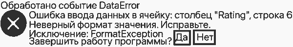

Рис. 2.15. Диалоговое окно сообщения об ошибке

Появление события `DataError` проиходит после события `CellValidation`, поэтому, если в обработчике события `CellValidation` обнаружено неправильное значение и установлено `е.Cancel=true`, то ячейка не принимается и её проверка системой не производится. В этом случае событие `DataError` не генерируется. **Обработчик события** `DataError` имеет следующий заголовок:

```
private void dataGridView1_DataError(object sender, DataGridViewDataErrorEventArgs e)
```

Если свойству `е.Cancel` присвоить значение `true`, то событие `DataError` будет отменено, и оно будет появляться, пока пользователь не введет в ячейку корректное значение. В противном случае (`false`) - неверное значение в ячейке будет заменено на исходное, а событие будет считаться обработанным. **Свойства параметра `е`**:

- `ColumnIndex` и `Rowindex` — обычно указывают ячейку, в которой произошла ошибка данных.
- `Context` - получает сведения о состоянии таблицы во время возникновения ошибки.
- `Exception` — получает исключение, представляющее ошибку. Имя исключения можно узнать следующим образом: `e.Exception.GetType().Name`

Полный текст программы приведен в разделе 2.17. Кроме проверки значений ячеек, иногда приходится решать другие задачи, например:

- получение доступа к новой добавленной и зафиксированой записи;
- подмена одного значения ячейки другим;
- подключение элемента управления для ввода значенияячейки;
- сортировка таблицы;
- формирование вычисляемого (свободного) столбца.

Страница 89

# 2.9. Форматирование значений

По умолчанию элемент управления `DataGridView` будет пытаться преобразовывать значение ячейки в формат, подходящий для отображения. Например, таблица будет преобразовывать числовое значение в строковое для отооражения в ячейке. Пользователь может указать используемые условия форматировани всех ячеек столбца или таблицы, задав свойство `Format` объект `DataGridViewCellStyle`. Этот объект может быть возвращен разными свойствами, например `DefaultCellStyle`. Однако изменить стиль отдельной ячейки или группы ячеек можно только в обработчике события, например, `CellFormatting`. Кроме того, используя свойство `Format`, нельзя выполнить замену значения, неравного `null`, другим значением. Например, нельзя число 0 заменить на текст "Значение не определено".

Страница 90

Если возможности стандартного форматирования являются недостаточными, можно настроить форматирование посредством обработки события `CellFormatting`. Это событие позволяет не только отобразить отформатированное значение, но и указать цвет фона, цвет переднего плана и другие стили, используемые для отображения значения. При этом исходное значение считывается из источника данных. **Обратите внимание**, событие `CellFormatting` не предназначено для форматированного ввода, как это делает, например, элемент управления `MaskedTextBox`. **Событие `CellFormatting`** происходит очень часто - всякий раз при прорисовке нобсарке каждой ячейки, например, когда наводится курсор на ячейку. Поэтому следует избегать использования продолжительных операций для обработки этого события. **Например**, ячейка имеет свойство `FormattedValue`. Если cвойство или метод `GetFormattedValue`, то происходит событие `CellFormatting`. Свойство `FormattedValue` является форматированным представлением значения, тогда как свойство `Value` ячейки — реальным значением свойства источника данных. К сожалению, свойство `FormattedValue` доступно только на чтение. **Обработчик события `CellFormatting`** имеет следующий заголовок:

```
private void dataGridView1_CellFormatting(object sender, DataGridViewCel|FormattingEventArgs e)
```

Свойства параметра **`е`**:

- `CellStyle` - получает или задает стиль форматируемой ячейки.
- `ColumnIndex` - получает индекс столбца, содержащего форматируемую ячейку.
- `RowIndex` - получает индекс строки, содержащей форматируемую ячейку.
- DesiredType - возвращает тип данных требуемого значения. Как правило, это `string`. Свойство `DesiredType` используется для определения того, возможно ли продолжение преобразования из одного типа в тип `string` или в другой тип.
- `FormattingApplied` — получает или задает значение, показывающее, было ли успешно отформатировано значение ячейки.
- `Value` — получает или задает неотформатированное значение свойства источника данных. Значение свойства можно прочитать, отформатировать и установить свойство `Value` на новое (отформатированное) значение, настроив таким обра зом значение, отображенное в таблице.

Страница 91

Чтобы указать, что другим обработчикам больше не требуется выполнять форматирование этого значения, задайте для свойсти `e.FormattingApplied` значение `true`, иначе - `false`. **Когда обработчик** событий закончит свою работу, то в случае, если свойство `е.Value` имеет значение `null` или имеет непро вильный тип, или свойство `e.FormattingApplied` имеет значени `false`, значение `Value` форматируется с помощью свойств `Formal`, `NullValue`, `DataSourceNullValue` и `FormatProvider` стиля ячеек, во вращенного свойством `е.CellStyle`, которое было инициализирова но с помощью свойства ячейки `InheritedStyle`. **Независимо от значения** `e.FormattingApplied`, стиль `e.CellStyle` используется для визуализации ячейки.

**Пример**. В некоторых задачах значение 0 в числовом поле свидетельствует об отсутствии значения. Однако отсутствующее значение должно отсутствовать, поэтому в следующем примере показано, как нулевые значения ячейки заменить пустой строк

```
private void dataGridView1_CellFormatting(object sender, DataGridViewCellFormattingEventArgs
{
    if (e.RowIndex >= dataGridView1.Rows.Count - 1)
        return;
    if (dataGridView1.Columns[e.ColumnIndex].Name == "room")
        if (e.Value. ToString() == "0")
    e.Value = "";
}
```

Показанный ранее способ использования формата $#$ для целочисленных ячеек не годится для ячеек типа `float` и `double`, так как значения, меньшие 0, будут показаны в виде пустой строки. Приведенный пример решает эту проблему.

Страница 92

# 2.10. Добавление свободных столбцов

**Свободный столбец** — это столбец, не привязанный к источнику данных. Добавление свободных столбцов к привязанной таблице — это комбинированный способ работы с данными. Чаще всего свободный столбец используют для хранения значений, вычисленных в процессе работы программы. Например, если в таблице в результате привязки отображаются оклады и премии, то свободный столбец может хранить зарплаты сотрудников. Свободный столбец иногда называют вычисляемым столбцом. **Свободный столбец** создается в окне «Правка столбцов» (см. рис. 2.7) путем добавления нового столбца с установкой флажка «Непривязанный столбец». Для этого столбца рекомендуется так-же установить значение «Только чтение». Для демонстрации использования вычисляемого столбца добавим в таблицу нашего приложения свободный столбец для хранения количества дней проживания клиентов в отеле. Введем следующие параметры столбца (см. рис. 2.16):

- Имя → days;
- Текст заголовка → "Кол-во дней"
- Только чтение → true.

Страница 93

```
Добавить столбец ? X
[ ] Столбец DataBound
Столбци в DataSource
    Room
    Date1
    Date2
    VIP
[ ] Непривязанный столбец
Имя: days
Тип: DataGridViewTextBoxColumn 	&forall;
Текст: заголовка: Кол во дней
[x] Видимый [x] Только чтение [ ] Зафиксирован
Btn: Добаить Btn: Отмена
```

Рис. 2.16. Добавление свободного столбца. (Что я, рисовать все это что-ли буду)

**Необходимо решить вопрос**, в какой момент вычислять ячейки свободного столбца. При этом необходимо учитывать, что при обновлении привязки таблицы к источнику данных с помощью метода ResetBindings, ячейки свободного столбца, как правила очищаются. В этом случае необходимо повторное вычислени значений всех ячеек свободного столбца. Для вычисления свободной ячейки текущей строки, в которой пользователь изменил какое-либо исходное значение, необходимо использовать соответствующий обработчик события. Таких cобытий достаточно много, например `RowValidated`, `RowValidatns`, `CellValidated`, `CellValueChanged`, `CellEndEdit` и др. Лучше всего но пользовать событие `RowValidating`, поскольку в нашей програми уже определен обработчик этого события, и в этом обработчие после положительной проверки ячеек можно вычислить значек свободной ячейки. Напомним, событие `RowValidating` возникает и при добавлении новой строки через интерфейс сетки.

Страница 94

Для вычисления значения свободной ячейки событие `RowValidated` может использоваться с тем же успехом, что и `RowValidating`, однако эти события не происходят при программном способе добавления новой записи или изменении значения ячейки. В этом случае следует вычислить значение свободной ячейки в том месте кода, где добавляется запись или изменяется значение ячейки, на основе которой вычисляется значение свободной ячейки. Цикл по всем строкам сетки для вычисления свободных ячеек необходимо выполнять после привязки таблицы к источнику данных. Кроме того, после выполнения метода ResetBindings ячейки свободного столбца очищаются, поэтому необходимо выполнить этот же цикл. Так как цикл должен выполняться в нескольких местах программы, рекомендуется создать отдельный метод с указанным циклом. Внесем изменения в нашу программу. Изменения показаны полужирным начертанием. Для экономии места старые фрагменты кода показаны многоточием. **В класс `Form1`**: `int rowAdd`; **В обработчик `Form1_Load`**:

```
private void Form1_Load(object sender, EventArgs e)
{
    // Наличие строки новой записи.
    rowAdd = dataGridView1.RowCount;
    // Создание списка клиентов - источника данных для таблицы.
    list.Add(
        new Client(
            "Иванов"
            , 101
            , new DateTime(2018, 04, 22)
            , new DateTime(2018, 05, 22)
            , false
        )
    );
    // Привязка BindingSource к списку.
    clientBindingSource.DataSource = list;
    // Вычисление значений ячеек свободного столбца.
    InitFreeCells();
}
```

Страница 95

Добавим мстод `InitFreeCelis` для вычисления значсний ячейки свободного столбца:

```
public void InitFreeCell()
{
    for (int Y = 0; Y < dataGridView1.RowCount - rowAdd;Y++)
    {
        DateTime dt1 = (DateTime)dataGridView1("date1", Y).Value;
        DateTime dt2 = (DateTime)dataGridView1("date2", Y).Value;
        TimeSpan days = dt2 - dt1;
        dataGridView1["days", Y].Value = (days.Days+1).ToString();
    }
}
```

В обработчик `dataGridView1_RowValidating`:

```
private void dataGridView1_RowValidating(object sender, DataGridViewCellCancelEventArgs e)
{
    //...
    TimeSpan days = dt2 - dt1;
    data GridView 1 ["days", Y].Value = (days.Days + 1).ToString();
    if (newRow)
    {
        //...
    }
}
```

Запустим программу. Получим окно, представленное на рис. 2.17.

Страница 96

```
Form1 _ O X
```

[output not shown]

```
Btn: Добавить Btn: Изменить Btn: Удалить
```

Рис. 2.17. Таблица со свободным столбцом

Существуют и другие способы заполнения свободных ячеек, однако приведенный выше способ хорошо вписывается в предложенную методику проверки значений ячеек.

Страница 97

# 2.11. Программное манипулирование записями

Мы уже видели, что вмешиваться в работу таблицы при использовании пользователем её стандартного интерфейса, достаточно непросто, и разработчик в этом случае должен обладать определенными знаниями. Программа получается значительно надежнее и проще, если отменить добавление и изменение записей через интерфейс таблицы и реализовать выполнение этих операций программным способом в отдельных формах. В нашем примере кнопки для отображения соответствующих форм мы уже добавили на главную форму (см. рис. 2.17). Для добавления новых объектов (записей) и изменения текушей строки будем использовать отдельные формы. Все изменения будем проводить в источнике данных, после чего будем обновлять отображение данных в таблице. Удаление выделенных строк можно не отключать, так как эта операция не связана с проверкой ячеек, однако с целью обеспечения единого интерфейса, будем использовать отдельную кнопку. В обработчике события `Click` этой кнопки будем запрашивать у пользователя разрешение на выполнение удаления. В некоторы программах можно сохранять удаленные строки в специальном хранилище и восстанавливать их по требованию.

Приступим к доработке нашего приложения.

**Во первых**. Для кнопок главной формы по двойному щелчку мыши создадим обработчики событий Click и переименуем их следующим образом:

```
button1_Click → b_Add_Click
button2_Click → b_Edit_Click
button1_Click → b_Del_Click
```

**Во вторых**. Добавим в проект две новые формы под именами `FormAdd` и `FormEdit`. Форма `FormAdd` будет предназначена для добавления новой записи, а форма `FormEdit` — для изменени текущей записи.

**В третьих**. На форму `FormAdd` добавим пять надписей `Label` и два текстовых поля ввода `TextBox` с именами `nameBox` и `roomBox`. Для свойств `Date1` и `Date2` добавим два элемено `DateTimePicker`. Для свойства `VIP` добавим элемент управления `CheckBox` с именем `checkBoxVIP`. Также добавим три кнопки `Button` с текстами "Добавить", "Очистить поля" и "Выход" с именами `b_Add`, `b_Clear` и `b_Close` соответственно. Создадим обработчики событий `Click` для этих кнопок. В результате проделанной работы должна получиться форма... Предполагается, что пользователь может добавить несколько записей, не закрывая форму.

Страница 98

```
Добавление клиента    _ O X
Фамилия:
Nº комнаты:
Дата заезда: 01 января 2018
Дата выезда: 01 января 2018
VIP персона: [ ]
Btn: Добавить Btn: Очистить поля Btn: Выход
```

Рис. 2.18. Форма для добавления новых записей

**В четвертых**. Объявим поле `list` в главной форме статическим, а у компонента `clientBindingSource` изменим в окне свойств уровень видимости на `public`.

**В пятых**. В обработчик `b_Add_Click` главной формы добавим следующий код для создания и отображения формы `FormAdd`:

```
FormAdd form = new FormAdd();
form.form1 = this;
form.ShowDialog();
```

**В пятых**. В классе `FormAdd` создадим обработчик `FormAdd_Load` и три обработчика для кнопок: `b_Add_Click`, `b_Clear_Click` и `b_Close_Click`.

Страница 99

Изменим класс FormAdd следующий образом:

```
public partial class FormAdd : Form
{
    public Form1 form1; // Ссылка на главную форму.
    bool add = false; // Признак добавления объекта в список
    public FormAdd() { InitializeComponent(); }
    private void FormAdd_Load(object sender, EventArgs e)
    {
        // Выводим тскущую дату.
        dateTimePicker1.Value = DateTime.Now.Date;
        dateTimePicker2.Value = DateTime.Now.Date;
    }
```

```
    private void b_Add_Click(object sender, EventArgs e)
    {
        // Проверяем поле Фамилия.
        if (string.IsNullOrEmpty(nameBox.Text))
        {
            form1.Msg ("Не введена фамилия. Введите.");
            nameBox.Focus();
            return;
        }
        // Проверяем поле Nº комнаты (гооm).
        if (string.IsNullOrEmpty(roomBox.Text))
        {
            form1.Msg("Не задан номер комнаты. Введите.");
            roomBox.Focus();
            return;
        }
```

Страница 100

```
        uint roomint;
        if (luint. TryParse(roomBox. Text, out roomint))
        {
            form1.Msg("Номер комнаты должен быть числом. Исправьте.");
            roomBox.Focus();
            return;
        }
        // Сравниваем даты.
        if (dateTimePicker1.Value > dateTimePicker2.Value)
        {
            form1.Msg("Дата приезда не может быть позже даты отъезда.");
            return;
        }
```

```
        // Добавим в список новый объект.
        Form1.list.Add(
            new Client(
                nameBox.Text
                , roomint
                ,dateTimePicker1.Value
                , dateTimePicker2.Value
                , checkBoxVIP.Checked
            )
        );
        MessageBox.Show("Клиент" + nameBox.Text + " добавлен.");
        add = true;
    }
```

```
    private void b_Clear_Click(object sender, EventArgs e)
    {
        nameBox.Text = "";
        roomBox.Text = "";
        checkBoxVIP.Checked = false;
        nameBox.Focus();
    }
    private void b_Close_Click(object sender, EventArgs e)
    {
        if (add) // Если в список был добавлен хотя бы один объект.
        {
            form1.clientBindingSource.ResetBindinas(falce);
            form1.clientBindingSource.ResetBindings(false);
            form1. InitFreeCells);
            // Вычисляем свободный столбец
        }
        Close();
    }
}
```

Страница 101

Обратите внимание: код, используемый для добавления нового объекта в форме `FormAdd`, значительно короче и проще кода выполнящего эту задачу в главной форме при использовании интерфейса таблицы. Для ускоренного создания формы `FormEdit` используем класс `FormAdd`. Скопируем код из файла `FormAdd.cs` в файл `FormEdit.cs` и из файла `FormAdd.Designer.cs` в файл `FormEdit.Designer.cs`. Этим мы сократим объем работы. Удалим среднюю кнопку и именим текст оставшихся кнопок по примеру рис. 2.19. Переиме нуем обработчики: `b_Add_Click` на `b_Edit_Click`, a `FormAdd_Load` на `FormEdit_Load`.

```
Добавление клиента _ O X
Фамилия: Сидоров
Nº комнаты: 201
Дата заезда: 15.июня.2018
Дата выезда: 30.июня.2018
VIP персона: [X]
Btn: Принять изменения Btn: Выход с отменой изменений
```

Рис. 2.19. Форма для изменения текущей записи

Страница 102

**В седьмых**. Далее выполним следующие изменения. Нам потребуется в форме `FormEdit` получить индекс текущей строки и вычислить свободную ячейку текущей записи, поэтому изменим в главной форме уровень видимости таблицы на `public`, чтобы таблицу было видно в форме `FormEdit`. **В восьмых**. Отредактируем класс `FormEdit` следующий образом:

```
public partial class FormEdit : Form
{
    public Formi form1; // Ссылка на главную форму.
    int i; // Индекс текущей записи.
    public FormEdit() { InitializeComponent(); }
    // Заполним поля формы значениями из текущей записи.
    private void FormEdit_Load(object sender, EventArgs e)
    {
        i = form1.dataGridView1.CurrentRow.Index;
        // Индекс текущей записи
        nameBox.Text = Form1.list[i].Name;
        roomBox.Text = Form1.list[i].Room.ToString();
        checkBoxVIP.Checked = Form1.list[i].VIP;
        dateTimePicker1.Value = Form1.list[i].Date1;
        dateTimePicker2.Value = Form1.list[i].Date2;
    }
```

```
    private void b_Edit_Click(object sender, EventArgs e)
    {
        // Проверяем поле Фамилия.
        if (string.IsNullOrEmpty(nameBox.Text))
        {
            form1.Msg ("Не введена фамилия. Введите.");
            nameBox.Focus();
            return;
        }
        // Проверяем поле Nº комнаты (rооm).
        if (string.IsNullOrEmpty(roomBox.Text))
        {
            form1.Msg("Не задан номер комнаты. Введите.");
            roomBox.Focus();
            return;
        }
```

Страница 103

```
        uint roomInt;
        if (!uint.TryParse(roomBox.Text, out roomint))
        {
            form1.Msg("Номер комнаты должен быть числом. Исправьте.");
            roomBox.Focus();
            return;
        }
        // Сравниваем даты.
        if (dateTimePicker1.Value > dateTimePicker2.Value)
        {
            form1.Msg("Дата приезда не может быть позже даты отъезда.
            return;
        }
```

Страница 104

```
        // Изменим свойства текущего объекта.
        Form1.list[i].Name = nameBox.Text;
        Form1.list[i].Room = roomInt;
        Form1.list[i].VIP = checkBoxVIP.Checked;
        Form1.list[i].Date1 = dateTimePicker1.Value;
        Form1.list[i].Date2 = dateTimePicker2.Value;
        // Обновим отображение записи.
        form1.clientBindingSource.ResetItem(i);
        // Вычислим свободную ячейку.
        TimeSpan days = dateTimePicker2.Value - dateTimePicker1.Value;
        form1.dataGridView1["days",", i]. Value = (days.Days + 1). ToString();
        Close();
    }
    private void b_Close_Click(object sender, EventArgs e)
    {
        Close();
    }
}
```

**В девятых**. В обработчике `b_Del_Click` необходимо определить, что удаляет пользователь - группу выбранных строк или текущую строку. Если группа строк выделена через свои заголовки, то будет предложено удалить эту группу. Если выделена одна строка, одна ячейка или группа ячеек, то будет предложено удалить только текущую строку. **Приведем код обработчика** `b_Del_Click`:

```
private void b_Del_Click(object sender, EventArgs e)
{
    if (dataGridView1.CurrentCell == null)
        return; // Если таблица пустая.
    if (dataGridView1.SelectedRows.Count > 1) // Если группа строк.
    {
        if(
            MessageBox.Show(
                "Вы действительно хотите удалить ГРУППУ СТРОК?"
                , "Внимание"
                , MessageBoxButtons.YesNo
                , MessageBoxIcon.Question) == DialogResult.Yes
        )
```

Страница 105

[output not shown]

```
    // Группы строк нет, есть одна текущая строка.
    string fam = (string)dataGridView1.CurrentRow.Cells["name"].Value;
    if (
        MessageBox.Show(
            "Вы действительно хотите удалить клиента "
            + fam
            + "?"
            , "Внимание"
            , MessageBoxButtons.YesNo
            , MessageBoxIcon.Question
        ) == DialogResult.No
    )
    { return; }
    list.RemoveAt(dataGridView1.CurrentRow.Index);
    clientBindingSource.ResetBindings(false);
}
```

Страница 106

Как видите, удаление группы строк — это более сложная задача по сравнению с удалением текущей строки. На этом мы закончили доработку приложения для программного выполнения таких операций, как добавление, изменение и удаление записей. **Как отменить добавление и изменение записей через интерфейс таблицы**. При разработке приложения для добавления новых записей и изменения существующих разработчик может **Во первых**, использовать только интерфейс таблицы; **Во вторых**, реализовать программное выполнение операций добавления и изменения записей; **В третьих**, использовать возможности 1 и 2 совместно. Можно ли во всех случаях использовать только стандартный интерфейс таблицы? Ответ: нет. Когда в таблице не все свойства источника данных отображаются (сложные типы), или разработчик не захотел отображать ряд столбцов, чтобы уменьшить размеры таблицы, то создать полноценную запись не удастся. Кроме того, не все ячейки можно будет изменить. Для решения таких задач возможно только программное манипулирование строками таблицы. Ранее мы отметили, что код программы с использованием отдельных форм для выполнения операций добавления и изменения получается короче, проще и надежнее. В этом случае для исключения ошибок следует заблокировать выполнение этих операций через интерфейс таблицы и реализовать выполнение этих операций в отдельных формах. Вместо форм можно использовать и вкладки. **Для блокирования добавления и изменения записей через интерфейс таблицы можно выполнить следующие настройки**:

- `AllowUserToAddRows=false` — убрать строку для добавления новой записи из таблицы.
- `ReadOnly=true` — запретить пользователю изменять ячейки непосредственно в таблице.

Как было отмечено, особых проблем с удалением записей клавишей `Delete` нет, но если Вы считаете, что лучше запретить эту операцию, то укажите в свойствах таблицы `AllowUserToDeleteRows = false`. Перечисленные свойства доступны также и в окне выбора настроек (см. рис. 2.6).

Страница 107

# 2.12. Фильтрация строк таблицы

Для отображения строк, удовлетворяющих некоторому критерию, следует в цикле отобрать подходящие строки. Иногда из таких строк создают новую коллекцию, а затем выполняют привязку таблицы к этой коллекции. Это способ имеет ряд недостатков, главным из которых является то, что такие операции, как добакление и удаление строк (объектов) из таблицы `DataGridView`, привязанной к коллекции отобранных строк, базовый список не затрагивают. Поэтому надо либо отказываться от этих операций, либо выполнять актуализацию (выравнивание) базового списка, что является еще одной задачей. Следует также заметить, что номера строк отобранных записей в таблице не соответствуют номерам объектов в базовом списке. Ниже предлагается способ, лишенный этих недостатков. Способ основан на использовании свойства `Row. Visible`, позволяющего скрыть ненужные строки. Данный способ прямого отношения к источнику данных не имеет, он ориентирован на строки таблицы, поэтому может быть применим к любым таблицам. Преимущества способа состоят в том, что не нужно создавать вторую коллекцию отобранных строк. Вместо этого, строки таблицы, не удовлетворяющие условию отбора, не отображаются (`...Row.Visible=false`). **При этом все строки** — отображаемые и неотображаемые - продолжают принадлежать таблице, и номера отобранных строк в процессе фильтрации остаются изначальными, поэтому добавление и удаление объектов осуществляется обычным образом. Есть одно небольшое ограничение в использовании свойсты `Visible`: нельзя делать невидимой строку с текущей ячейкой, поэтому в программе перед фильтрацией строк следует отменит выделение текущей ячейки с помощью оператова. Приведем пример фильтрации строк, доработав наше приложение. Добавим на главную форму текстовые строки и кнопки, используемые для отбора (см. рис. 2.20). Особенность используемого многокритериального способа отбора строк таблицы состоит в том, что используются только непустые элементы TextBox и по их значениям отбираются строки, которые одновременно удовлетворяют всем заданным критериям.

Страница 108

```
Form1 _ O X
```

|  | Фамилия | № комнаты | Даты заезда | Даты отьезда | VIP | Koл-во дней |
| --- | --- | --- | --- | --- | --- | --- |
| ► | Иванов | 101 | 22.04.2018 | 22.05.2018 | [ ] | 31 |
|  | Николаев | 103 | 12.05.2018 | 22.07.2018 | [ ] | 72 |
|  | Сидоров | 201 | 15.06.2018 | 30.06.2018 | [ ] | 16 |
|  | Титов | 202 | 13.07.2018 | 22.07.2018 | [X] | 10 |
|  | Сергеев | 205 | 19.08.2018 | 22.08.2018 | [ ] | 4 |
| 🤼 | --- | --- | --- | --- | [ ] | --- |

```
Btn: Добавить Btn: Изменить Btn: Удалить
Фамилия: ___
№ комнаты: ___
Vip: [ ]
Дата заезда: ___
Дата отьезда: __
Btn: Отобрать Btn: Очистить Btn: Показать всех
```

Рис. 2.20. Форма с критериями отбора записей

Страница 109

Создайте обработчики кнопок «Отобрать», «Очистить» и «Показать всех». Измените имена обработчиков на более понятное (см. в коде) и вставьте в них код из следующего фрагмента:

```
// Отбор клиентов по совокупности критериев.
private void b_Отобрать_Click(object sender, EventArgs e)
{
    dataGridView1.CurrentCell = null;
    for (int i = 0; i < dataGridView1.Rows,Count - rowAdd; i++)
    {
        if (TestRow(i))
        { dataGridView1.Rows(I].Visible = true; }
        else
        { dataGridView1.Rows[i].Visible = false; }
    }
}
```

```
// Метод проверяет ячейки переданной строки
// на одновременное равенство всем критериям.
private bool TestRow(int i)
{
    if(nameTextBox.Text != "" && list[i].Name != nameTextBox.Text) return false;
    if(roomTextBox.Text != "" && list[i].Room.ToString() != roomTextBox.Text) return false;
    if(date1TextBox.Text!= "" && list[i].Date1 != DateTime.Parse(date1TextBox.Text)) return false;
    if(date2TextBox.Text!= "" && list[i].Date2 != DateTime.Parse(date2TextBox, Text)) return false;
    if(VIPcheckBox.Checked && !list[i].VIP) return false;
    return true;
}
```

Страница 110

[output not shown]

**Во вторых**. Используем лямбда-выражение:

```
list.Sort((al, a2) => a1.Name.CompareTo(a2.Name));
```

Достоинством метода `Sort` является то, что сортировка выполняется на месте. Кроме того, если у значения, возвращаемого анонимным методом делегата, поменять знак, то сортировка будет выполняться по убыванию. Для выполнения сортировки как по возрастанию значений, так и по убыванию добавим два элемента `RadioButton` (см. рис. 2.21). Если будет задана сортировка по убыванию, то умножим возвращаемое методом делегата значение на -1.

```
Табличное отображение данных _ O X
Порядок сортировки: [X] по возрастанию [] по убыванио
```

|  | Фамилия | № комнаты | Дата заезда | Дата Отъезда | VIP | Кол-во дней |
| --- | --- | --- | --- | --- | --- | --- |
| ► | Иванов | 101 | 22.04.2018 | 22.05.2018 | [ ] | 31 |
| ... | ... | ... | ... | ... | ... | ... |

```
btn: Добавить
btn: Изменить
```

Рис. 2.21. Фрагмент окна с переключателями порядка сортировки

Страница 111

Щелчок заголовка столбца генерирует событие **ColumnHeaderMouseClick**. Создадим в нашем приложении обработчик этого события и вставим в него следующий код:

```
private void dataGridView1_ColumnHeaderMouseClick(object sender, DataGridViewCellMouseEventArgs e)
{
    if (dataGridView1.Rows.Count > rowAdd)
    {
        // Установим порядок сортировки.
        int d = radioButton1.Checked == true ? 1 : -1;
        switch (dataGridView1.Columns[e.ColumnIndex].Name)
        {
            case "name":
            list.Sort(delegate (Client a1, Client a2)
                { return d * a1.Name.CompareTo(a2.Name); 7);
            break;
            case "room":
            list.Sort(delegate (Client a1, Client a2)
                { return d * a1.Room.CompareTo(a2.Room); });
            break;
            case "date1":
            list.Sort(delegate (Client a1, Client a2)
                { return d * a1.Date1.CompareTo(a2.Date1); });
            break;
```

```
            case "date2" :
            list. Sort(delegate (Client al, Client a2)
                { return d * a1.Date2.CompareTo(a2.Date2); });
            break;
            default: // По другим столбцам сортировки не будет.
                 return;
        }
        clientBindingSource.ResetBindings(false);
        InitFreeCells(); // Вычисление значений свободного столбца
    }
}
```

Некоторые списки, например `BindingList`, не имеют своего метода `Sort`, однако им доступен метод расширения `OrderBy`, параметром которого является делегат функции, извлекающей свойство объекта. Этот параметр удобно определять в виде лямбда-выражения. Недостатком метода `OrderBy` является то, что он возвращает отсортированную последовательность типа `IEnumerable<TSource>`, которую затем необходимо представить в виде списка `list`.

Страница 112

**Пример**. Отсортировать список `list` по свойству `Client.Name` с помощью метода `OrderBy`.

```
case "name":
    list = list.OrderBy(client => client.Name). ToList();
    clientBindingSource.DataSource = list;
    InitFreeCells);
    return;
```

Поскольку метод `OrderBy` создает новый список, то вместо обновления привязки:

```
clientBindingSource.ResetBindings(false);
```

необходимо использовать повторную привязку:

```
clientBindingSource.DataSource = list;
```

Метод `OrderBy` по умолчанию сортирует записи по возрастанию. Для сортировки по убыванию используется мeтод `OrderByDescending`.

Страница 113